# Python_for_Introductory_Statistics_V2

## Page Contents

[figure not shown]

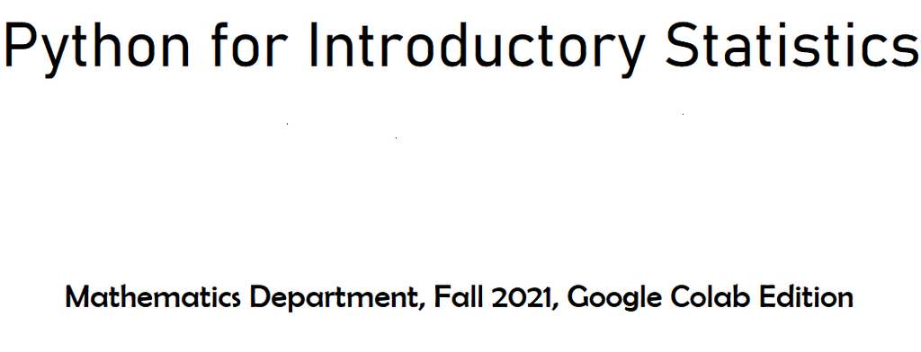

**Purpose and Overview**

The purpose of this material is to provide an overview of the free programming language, Python, and a few of its software *libraries* that are most useful for improving Introductory Statistics students' learning and for providing an alternative statistical software package for those who perform statistical data analysis and plotting. This material, along with the companion workbook and a free web-based Python platform, could easily replace the use of other software packages and calculators in an Introductory Statistics course. Part I, Sections 1 to 4, covers the basics of the Python programming language. Part II, Sections 5 to 13, focuses on Python for introductory statistics, and Part III, Section 14, covers selected advanced statistics topics in Python. Additionally, there are demo video links accompanying key steps for further instruction. No prior programming knowledge is required or assumed.

Questions, comments or errors can be reported by sending an email to saman2@ccc.edu. A link to an interactive Colab version of this document can be found in this [interactive Colab workbook](https://colab.research.google.com/drive/1KUWhhadNOGZTuWEVEU6EIK3J5zDBXAtN?usp=sharing).

**Keyboard Shortcut for HTML (Web Link) and PDF Users**: When you click an external link and want to go back to where you were before the click, use the keyboard shortcut `Alt` and `Left-Arrow` for Windows and `Command` and `Left-Arrow` for Mac.

© 2021 Simon Aman, City Colleges of Chicago. Special thanks to reviewers, Professor Phil Yates of DePaul University and Professor Aman Ghebremicael of Arizona Western College.

This material is licensed under [Creative Commons Attribution 4.0 International (CC BY 4.0)](https://creativecommons.org/licenses/by/4.0/).

0. Why Learn Python?
1. Introduction to Python
   - 1.1 Getting Started
   - 1.2 Python Arithmetic Operators
   - 1.3 Python Variables
   - 1.4 Python Comments
   - 1.5 The NumPy Library
   - 1.6 `input` Data From Keyboard
2. Python Lists
   - 2.1 Creating and Accessing Lists
   - 2.2 List Operations
3. Python Syntax
   - 3.1 `if` Statements
   - 3.2 Functions
   - 3.3 Syntax Errors
4. Python Loops
   - 4.1 The `for` Loop
   - 4.2 The `while` Loop
5. Frequency Distributions and Graphs
   - 5.1 Frequency Counts
   - 5.2 The Matplot Library
   - 5.3 Bar Graphs and Pie Charts
   - 5.4 Histogram, Polygon and Ogive
   - 5.5 Dot Plot
   - 5.6 Stem-and-leaf
   - 5.7 Scatter Plot
6. Measures of Center and Spread
   - 6.1 Mean and Median
   - 6.2 Variance
   - 6.3 Standard deviation
     - Weighted Mean and std
   - 6.4 Grouped mean and standard deviation
7. Measures of Position
   - 7.1 Percentiles
   - 7.2 SciPy and Percentile Rank
   - 7.3 Box Plot
8. Discrete Probability Distributions
   - 8.1 Mean (Expected Values) and Standard-Deviations
   - 8.2 Binomial Probability Distribution
     - Binomial Plot
9. Continuous Probability Distributions
   - 9.1 Uniform Probability Distribution
   - 9.2 Normal Probability Distribution
   - 9.3 Central Limit Theorem - Mean
10. Confidence Intervals
    - 10.1 Confidence Intervals for Mean (z distribution)
    - 10.2 Confidence Intervals for Mean (t distribution)
    - 10.3 Confidence Intervals for Proportions
      - Calculating Sample Size n
11. Hypothesis Testing
    - 11.1 Hypothesis Testing: Mean z test
    - 11.2 Hypothesis Testing: Mean t test
    - 11.3 Hypothesis Testing: Proportion z test
12. Linear Regression and Correlation
    - 12.1 Scatter Plot
    - 12.2 Correlation
    - 12.3 Linear Regression
      - Predictions
13. Analysis of Categorical Data
    - 13.1 Goodness of Fit
    - 13.2 Test of Independence
14. Advanced Topics
    - 14.1 Descriptive Statistics with Pandas
      - Pandas Library
      - Frequency and Relative Frequency
      - Descriptive Stats with Pandas
      - Mode
      - Percentiles
      - Summary stats, Skewness and Kurtosis
    - 14.2 Uploading Excel Data
      - Descriptive Statistics (multiple columns)
    - 14.3 Visualization
    - 14.4 Regression
      - Multiple Linear Regression
      - Logistic Regression
    - 14.5 ANOVA
      - One-way ANOVA
      - Tukey Paired Mean
      - Two-way ANOVA
      - Two-Factor ANOVA
- Appendix 1: Python Installation
- Appendix 2: Random Integer Generator
- Appendix 3: Factorial
- Code References
- Resources Links

# 0. Why Learn Python?

Artificial intelligence is changing how people write code, but it does not eliminate the need for introductory statistics students to learn Python. In this book, Python is not presented as an end in itself. It is a practical tool for learning how to think clearly about data, statistical methods, and the questions we want analysis to answer.

## If AI tools were not available

If students were not allowed to use AI assistants, Python knowledge would be essential because they would need to:

- understand data structures and data cleaning
- translate statistical procedures into computational steps
- debug errors and recognize when code is wrong
- verify that a method actually matches the research question
- carry out analysis without relying on outside automation

In that setting, Python literacy would be foundational rather than optional.

## When AI tools are available

In many future workplaces, students will likely have access to AI-powered coding tools. Even then, the real value of learning Python remains strong. Students still need to:

1. understand the statistical question well enough to ask for the right analysis
2. judge whether AI-generated code is correct
3. notice when an answer is incomplete, misleading, or wrong
4. ask better follow-up questions and refine an analysis thoughtfully

AI can help with syntax and code generation, but it cannot replace statistical understanding.

## What students gain by learning Python

When students write Python code to load data, compute summary statistics, create graphs, and perform statistical tests, they are also learning how statistical reasoning works in practice. They become better able to:

- recognize common analysis patterns
- connect formulas to data workflows
- interpret output rather than just produce it
- trust but verify automated results
- adapt an analysis to a new situation

In that sense, learning Python supports statistical literacy, not just programming skill.

## What AI cannot do for students

AI can generate code, but several parts of statistics still require human judgment:

- **Problem framing:** deciding what question should be asked and what kind of study or model is appropriate
- **Ethical reasoning:** identifying bias, fairness issues, and the consequences of analytical choices
- **Interpretation:** deciding whether results are practically meaningful, not just statistically significant
- **Communication and accountability:** explaining findings clearly and taking responsibility for the conclusions

These are human responsibilities, and they become more important, not less, in an AI-enabled world.

## Conclusion

The goal of this material is not to turn every student into a software developer. The goal is to help students become informed users of data and statistics. Python provides a powerful way to practice that thinking. In the age of AI, Python literacy still matters because students must understand enough to guide the tools they use, evaluate what those tools produce, and make responsible statistical decisions.

# 1. Introduction to Python

## 1.1 Getting Started

Python is a general-purpose simple-syntax programming language created by Guido van Rossum in 1989. Python is widely used for scientific computing, data science, web development, machine learning, artificial intelligence and other advanced fields. Google, NASA, Netflix, and YouTube are some of the large organizations that use Python.

**Google Colaboratory Notebook** (**Colab** for short) is a free web-based Google product, similar to Google Docs, that requires no software installation for Python programming. A Colab Notebook is a list of **cells** created by adding a **code** or a **text** cell. When you create your own Colab notebooks, they are stored in your Google Drive account.

### To Open a New Colab Notebook

[Watch demo video](https://youtu.be/2tYSkFevQdU)

1. Click [this link](http://colab.research.google.com#create=true)
2. Sign in with your Google account. If you are already signed in, continue to the next step. You can create a free [Google account](https://accounts.google.com/SignUp?hl=en)
3. Click **New Notebook** from the bottom-right of the pop-up window **Note**: It may open a new notebook automatically sometimes.

**Note**: Google Colab Notebook (Picture Below)

[figure not shown]

### To Write Your First Python Code

1. Click the code-cell next to the `play` button
2. Type `print("Hello, World!")`

See picture below

[figure not shown]

### To Execute(run) Your First Python Code

1. Click the `play` button located before `print("Hello, World!")`
2. Or click your first Python code and press Ctrl and Enter on your keyboard. **Note**: It is Command and Enter for Mac(Apple) computers.
3. `Hello, world!` is displayed on a new line

[figure not shown]

### To Edit the Code

1. Click the code-cell with `print("Hello, World!)"`
2. Start editing

**Note**: The Python `print()` function takes in `arguments` inside parenthesis and prints(displays) them in one line. In the above code, what happens if you leave out one of the quotation marks? `print("Hello, World!)` or parentheses `print("Hello, World!"` or misspelled the word print `prnit("Hello, World")`? In all these cases, you will face error messages. Computer programming languages are literal and unambiguous. It expects *everything* to be accurate. Learning to identify and fix the causes of errors, **debugging**, is an important skill in programming.

### To Write Your Second Python Code

1. Click `+ Code` in your notebook
2. Type `10+10` in the new code cell
3. Click the `play` button
4. The output `20` is displayed on a new line

[figure not shown]

**Note**: In the first code above `Hello, World!` was in double quotation marks. But in this example `10+10` is not in quotation marks. Python recognizes anything in quote, such as, "Hello, World!" as string **data type**, `str`, whereas `10` is recognized as an integer data type, `int`. Decimal numbers such as `10.1` are recognized as `float` data type.

**Note**: If you prefer **not** to use Google Colab Notebook, you can install free Python in your computer. See appendix 1 for details.

## 1.2 Python Arithmetic Operators

| Name | Operator | Example | Result |
| --- | --- | --- | --- |
| Addition | `+` | `5+6` | `11` |
| Subtraction | `-` | 5-6 | `-1` |
| Multiplication | `*` | `5*6` | `30` |
| Division | `/` | `5/6` | `0.83333` |
| Exponentiation | `**` | `5**2` | $5^2$ =`25` |

### To Write Your Third Python Code

$7\times95$

1. Click `+ Code` on a notebook to add a code cell
2. Type `7*95`
3. Press the `play` button to execute the code
4. `665` is the result

[figure not shown]

### To Save Your Colab Notebook

[Watch demo video](https://youtu.be/wIiwVwdJaCM)

1. Click `Untitled.ipynb` at the top of the notebook
2. Delete the title and replace it by typing `python1`
3. Press the `enter` key
4. The file `python1` is now saved in your Google Drive
5. Click File and then Save
6. Close your browser

[figure not shown]

### To Open Your python1 Notebook

1. Click this link http://colab.research.google.com#create=true or go to your [Google Drive](https://drive.google.com/).
2. Click `python1` from the list on the pop-up window
3. The notebook will open

OR click the File menu then Open Notebook

[figure not shown]

**Note**: For the examples below:

1. Add a new code cell on a Colab notebook
2. Type the code based on the statement of the example
3. Execute the code

Example: Multiply $5\times6$

```python
5*6
```

```
30
```

Example: Divide $10\div 3$

```python
10/3
```

```
3.3333333333333335
```

Example: Exponentiate $5^2$

```python
5**2
```

```
25
```

Example: Add and then divide

$(2+3+5+4)\div4$

```python
(2+3+5+4)/4
```

```
3.5
```

**Note**: If you want to add the numbers in the numerator $2+3+5+4$ first and then divide it by the denominator, $4$, you will need to **save** the sum of the numerator first. We will cover how to save the sum in a **variable name** in the next section.

Example: Add $\frac{1}{2} + \frac{1}{3} + \frac{2}{5} + 10$

```python
1/2+1/3+2/5+10
```

```
11.233333333333334
```

**Note**: Adding parentheses to the fractions makes it clearer (see below)

```python
(1/2)+(1/3)+(2/5)+10
```

```
11.233333333333334
```

Example: Perform the operations $6\div3\times7-6.7+3.5$

```python
6/3*7-6.7+3.5
```

```
10.8
```

Example: Perform the operations $43+(8-5)^3\div(34-5^2)$

```python
43+(8-5)**3/(34-5**2)
```

```
46.0
```

Example: Perform the operation $13\frac{1}{2}+2.4\times1.4^2$

```python
13+1/2+2.4*1.4**2
```

```
18.204
```

**Note**: Radicals in Rational Exponents [Watch demo video](https://youtu.be/xHP1W-f94Us)

If $x$ is a real number, $a$ is integer and $b$ is positive integer then

$\sqrt[b]{x^a} = x^{\frac{a}{b}}$

For example:

$\sqrt8=8^{1/2}$

$\sqrt[3]8=8^{1/3}$

$\sqrt[4]{8^3}=8^{3/4}$

Example: Evaluate $\sqrt7=7^{1/2}$

```python
7**(1/2)
```

```
2.6457513110645907
```

```python
7**.5
```

```
2.6457513110645907
```

**Note**: `1/2 = .5`

Example: Evaluate $\sqrt[3]7$

$\sqrt[3]7=7^{1/3}$

```python
7**(1/3)
```

```
1.912931182772389
```

Example: Find $\sqrt{5^2-4}$

**Note**: $\sqrt{5^2-4}=(5^2-4)^{1/2}$

```python
(5**2-4)**(1/2)
```

```
4.58257569495584
```

Example: Follow standard math order of operations to evaluate:

$\sqrt{5^2-4\times2\times(-3)}$

**Note**: $\sqrt{5^2-4\times2\times(-3)} = (5^2-4\times2\times(-3))^{1/2}$

```python
(5**2-4*2*(-3))**(1/2)
```

```
7.0
```

Example: Follow standard math order of operations to evaluate:

$-2+\sqrt{5^2-4\times2\times(-3)}$

**Caution**: Everything under the square root is inside a parenthesis raised to 1/2. That is $5^2-4\times2\times(-3)$ is raided to $1/2$. You can do this in two steps using variables in the next section

```python
-2+(5**2-4*2*(-3))**(1/2)
```

```
5.0
```

Example: Evaluate:

$\frac{-2+\sqrt{5^2-4\times2\times(-3)}}{2\times2}$

Notice how paired parentheses are used to enforce order of operations.

```python
(-2+(5**2-4*2*(-3))**(1/2))/(2*2)
```

```
1.25
```

### Scientific Notations

Example: Divide $\frac{1}{186000}$

```python
1/186000
```

```
5.376344086021505e-06
```

**Note**: The Python output `5.376344086021505e-06` is in scientific notation. $5.376344086021505e-06 = 5.376344086021505\times10^{-6}$

## 1.3 Python Variables

[Watch demo video](https://youtu.be/Afee6voBzkA)

A variable is a location that stores temporary data within a program. Variables can be modified, stored or displayed whenever needed. Variables that you define in one cell can later be used in other cells.

In Python, variables are defined, created, and declared once you assign a value to it. Variable names can be arbitrarily long and can contain both letters and numbers, but they have to begin with a letter. Avoid using one of Python's **keywords** (reserved words) such as `print`, `input`, `and`, `or`, `def`, `if` etc. Here is a link to the complete [list](https://www.w3schools.com/python/python_ref_keywords.asp).

The **equal sign** `=` is called the assignment operator. It takes the value of the right-hand side of the equal sign and *assigns* it to the variable name on the left side of the equal sign.

Example: Find the average of three test scores: $75, 80$ and $90$? The average is found by adding the three test scores first and then dividing the total by 3.

1. Click `+ Code` to add a code cell
2. Type `total = 75+80+90`
3. Type `total/3`
4. `81.66666666666667` is the result

```python
total = 75 + 80 + 90
total/3
```

```
81.66666666666667
```

Example: Find the average of three test scores: $75, 80$ and $90$? The average is found by adding the three test scores first and then dividing the total by 3. Save the average in a variable named `ave`

1. Click `+ Code` to add a code cell
2. Type `total = 75+80+90`
3. Type `ave = total/3`
4. Type `print(ave)`
5. `81.66666666666667` is the result

```python
total = 75+80+90
ave = total/3
print(ave)
```

```
81.66666666666667
```

**Note**:

- The value of `75+80+90` is evaluated and stored in `total`
- The value of `total` from line one is used to evaluate `total/3` in the second line and the new value of `total/3` is stored in `ave`.
- `print(ave)` is used to display the value stored in `ave`

**Note**: In a code-cell with multiple lines, the program executes one line at a time in sequence from top to bottom.

Example: Evaluate $\frac{2+3+5+4}{4}$ by storing the sum of the numerator in a variable named `numerator_sum` first. Then add another line that divides this sum by 4.

1. Click `+ Code` to add a code cell
2. Type `numerator_sum = 2 + 3 + 4 + 5`
3. Type `numerator_sum/4` on a new line. (It will display the value of `numerator_sum/4`)
4. Press the `play` button
5. `3.5`, the value of the last executed line is displayed

```python
numerator_sum = 2 + 3 + 5 + 4
numerator_sum/4
```

```
3.5
```

Example: $-2+\sqrt{5^2-4\times3\times(-3)}$

```python
radicand = 5**2 - 4*3*(-3)
-2 + radicand**(1/2)
```

```
5.810249675906654
```

**Note**: In Python, the same variable name can be used to store different values multiple times, but only the last assignment is stored for future use. The old value is **updated** every time a new value is assigned. See example below.

**Note**: The `print()` function displays anything in quotes as is but variable names are not in quotes and are separated from the quote by a comma.

```python
a = 0
print('The first value of a is',a)
a = 10
print("The updated second value of a is ",a)
a = a + 5
print( 'The last updated, third value, of a is ', a)
```

```
The first value of a is 0
The updated second value of a is  10
The last updated, third value, of a is  15
```

**Note**:

1. In the first line `a = 0`, zero is stored in `a`.
2. In the third line `a = 10`, 10 is assigned to `a`. Here the value of `0` that was stored in `a` is updated(replaced) by `10`.
3. In the fifth line, `a = a + 5`, the `a + 5` on the right side of the equal sign is evaluated as `10 + 5`. This is because `10` was stored in `a` from line 3. Then `10 + 5` is stored in `a` replacing the previous value of `10`.
4. The last line, `a` is displayed with its last updated value of `15`.

### Deleting a Variable

Use the **keyword** `del` to delete a variable. See example below.

```python
seconds_in_week = 60*60*24*7
del seconds_in_week
print(seconds_in_week)
```

```
---------------------------------------------------------------------------
NameError                                 Traceback (most recent call last)
<ipython-input-403-cf943aec5ccc> in <module>()
      1 seconds_in_week = 60*60*24*7
      2 del seconds_in_week
----> 3 print(seconds_in_week)

NameError: name 'seconds_in_week' is not defined
```

Example: A line that passes through two ordered-points $\ (x_1,y_1)$ and $\ (x_2,y_2)$ has slope, $m=\frac{y_1-y_2}{x_1-x_2}$ where $x_1 \ne x_2$. Use this formula to find the slope of a line that passes through $\ (2,5)$ and $\ (4,7)$. See code below.

```python
x1 = 2
y1 = 5
x2 = 4
y2 = 7

m = (y1-y2)/(x1-x2)
m
```

```
1.0
```

## 1.4 Python Comments

Comment is some text in a computer program that is for the human reader and is ignored by the computer when running the program. In Python one line comments begin with a hash symbol `#`. Anything written after the keyboard key hash `#` till the end of the line is considered *comment* and Python does not execute comments. multiple line comments can be done by enclosing them in triple quotes """. Comments (notes) are useful to explain what the program is doing. See example below.

```python
# find the slope of a line that passes through (2,5) and (4,7)
x1 = 2    # 2 came from the given point (2,5)
y1 = 5
x2 = 4    # 4 came from the second point (4,7)
y2 = 7

m = (y1-y2)/(x1-x2)    # this is the formula for a slope
print(m)

""" Or you can directly substitute the given number in to
the formula. See the code below """

m = (5-7)/(2-4)
print("the second way",m)
```

```
1.0
the second way 1.0
```

## 1.5 The NumPy Library

[Watch demo video](https://youtu.be/jhA5dbrmAXs)

In Python, a software library is a reusable collection of code. NumPy, pronounced "Num-Pie" for Numerical Python is the fundamental package for scientific computing with Python. https://numpy.org/

Unlike `print()` which is a built-in function, we need to `import` numpy before using its functions such as `numpy.absolute()`. Importing refers to allowing Python to access the script from another Python module or library. The numpy library provides access to an extensive mathematical functions.

`import numpy`

To access one of its functions, specify the name (or its alias) of the library and the name of the function, separated by a dot(period).

**Some Python Functions (Methods) from the numpy library**

| Name | Method | Example | Results (rounded) |
| --- | --- | --- | --- |
| Square root | `numpy.sqrt(x)` | $\sqrt{5}$ | `2.23606797749979` |
| Absolute value | `numpy.absolute(x)` | -5 | `5` |
| Rounding | `numpy.round(x,2)` | 1.3333 | 1.33 |
| the number pi | `numpy.pi` | $\pi$ | `3.141592653589793` |
| e | `numpy.e` | `e` | `2.718281828459045` |
| e raised to | `numpy.exp(x)` | $\ e^2$ | `7.38905609893065` |
| Natural log | `numpy.log(x)` | $\ln 5$ | `1.6094379124341003` |
| Common log | `numpy.log10(x)` | $\log(9)$ | `0.9542425094393249` |

Example: Given the formula $\ E = |z|\sqrt{\frac{p(1-p)}{n}}$, evaluate $\ E$, if $\ z=-2.575$, $\ p=0.34$, and $\ n=800$.

Option 1: substitute all into the formula

```python
import numpy as np
np.absolute(-2.575)*(0.34*(1-0.34)/800)**(1/2)
```

```
0.043126445627943884
```

Option 2: use some variables to break-down the steps

```python
import numpy as np
a = 0.34*(1-.34)/800
b = a**(1/2)
np.absolute(-2.575)*b
```

```
0.043126445627943884
```

Option 3: declare z, p and n as variables and assign the given values first then use the formula to evaluate E using these variables:

```python
import numpy as np
z = -2.575
p = 0.34
n = 800
E = np.absolute(z)*(p*(1-p)/n)**(1/2)
E
```

```
0.043126445627943884
```

Example: Round the value of $\frac{1}{3}$ to two decimal places.

```python
import numpy as np
np.round(1/3,2)
```

```
0.33
```

Example: Round the value of $\sqrt2$ to three decimal places.

```python
import numpy as np
np.round(2**(1/2),3)
```

```
1.414
```

Example: What is the (rounded) value of $\pi$ in Python?

1. Click `+ Code`
2. Type `import numpy`
3. Type `numpi.pi`
4. Click `play` button to execute the code
5. `3.141592653589793` (displayed)

```python
import numpy
numpy.pi
```

```
3.141592653589793
```

Example: Area of a circle with radius r is given by the formula $\ A = \pi r^2$

- Find the area of a circle with radius 5.
- Round your answer to a whole number.
1. Type `import numpy`
2. Type `numpy.pi*5**2` on the second line
3. Click `play` to execute the code

```python
import numpy
numpy.pi*5**2
```

```
78.53981633974483
```

```python
import numpy
Area = numpy.pi*5**2
round(Area,0)
```

```
79.0
```

Example: what is the rounded value of $e^3$?

```python
import numpy
numpy.exp(3)
```

```
20.085536923187668
```

Example: what is the rounded value of $\sqrt3$?

```python
numpy.sqrt(3)
```

```
1.7320508075688772
```

Example: use ** to find $\sqrt3$

```python
3**(1/2)
```

```
1.7320508075688772
```

## 1.6 Input data from Keyboard

[Watch demo video](https://youtu.be/ism7PT9hAhI)

**input()**

We used the `print()` function to display program output. The `input()` function is used to read user input from the keyboard. When the built-in-function `input()` is called, the program stops and waits for the user to type from the keyboard. When the user presses Return or Enter, the program resumes and `input` returns what the user typed as a `string` data type by default.

1. Click `+ Code` to add a code-cell
2. Type `x = input()`
3. Type `print(x)`
4. Click `play`
5. Type the number 2 using your keyboard and press `enter`.

See code below

```python
x = input()
print(x)
```

```
2
2
```

**Note**: The value of `input()` entered from the keyboard is stored in `x`

It is a good practice to print a prompt telling the user what to input. For example, `input("what is your name?")` will make it clear to the user what to enter. See code below.

1. Click `+ Code`
2. Type `x = input("What is your name? ")`
3. Type `print("Your name is", x)`
4. Click `play`
5. Enter `Don` from your keyboard

```python
x = input("What is your name? ")
print("Your name is",x)
```

```
What is your name? Don
Your name is Don
```

**Note**: The value of `input()` entered by the user is stored in `x`. That is `x = Don`

### Input Examples

Example: Write a Python program that accepts an integer $x$ and computes and prints the square-root of $x$. See code below.

```python
x = input("Enter any integer number: ")  #ask the user for a number
x = int(x)              # converts the input from string to integer (casting)
y = x**.5
print("The square-root is", y)
```

```
Enter any integer number: 5
The square-root is 2.23606797749979
```

Example: Write a Python program which asks the user for a radius of a circle and displays the area using the formula $A=\pi r^2$. See code below.

```python
r=input("Enter the radius of a circle: ")  #ask the user for radius
r=float(r)              # converts the string to float
import numpy      # we need the number pi
area = numpy.pi*r**2
print("The area of the circle is", area,'square units')
```

```
Enter the radius of a circle: 6
The area of the circle is 113.09733552923255 square units
```

Example: Write a Python program to calculate adult body mass index for a given weight in pounds and height (feet and inches) using the formula, $BMI = 703\frac{weight(lb)}{height(in)^2}$. See code below.

```python
w=input("Enter weight in pounds:")  #ask the user for a number
h1 = input("Enter height feet only:")
h2 = input("Enter inches:")
w,h1,h2 = float(w),float(h1),float(h2) # converts the number to float
bmi = 703*(w/(h1*12+h2)**2)
print("The BMI is", bmi)
```

```
Enter weight in pounds:60
Enter height feet only:5
Enter inches:2
The BMI is 10.972944849115505
```

# 2. Python Lists

[Watch demo video](https://youtu.be/SClBYDOqN-E)

In Python, lists are used to store multiple items in a single variable. Lists are created using square brackets separated by commas. List items, called elements, are ordered, changeable, and allow duplicate values.

## 2.1 Creating and Accessing Lists

Example: Create a Python list of 24, 22, 5, 34, 81, and 10. Save the list to the variable name `my_list` and display it.

1. Click `+ Code` to add a code-cell
2. Type `my_list = [24,22,5,34,81,10]`
3. Type `my_list`
4. Click `play` button

```python
my_list = [24,22,5,34,81,10]
my_list
```

```
[24, 22, 5, 34, 81, 10]
```

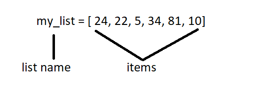

Example: Create a list named x using the following integers: 10, 14, 20 and 15. Print the list.

```python
x = [10,14,20,15]
x
```

```
[10, 14, 20, 15]
```

Example: Create a list named x using the following colors: red, yellow, green and blue. Print the list.

```python
y = ['red','yellow','green','blue']  # string data in quotes
y
```

```
['red', 'yellow', 'green', 'blue']
```

List elements are **indexed**, and we can use the index operator `[]` to access its elements. The first element has index 0, the second element has index 1 etc.

Example: Create a list of 24, 22, 5, 34, 81 and 10. Save the list in `x` and display the entire list .

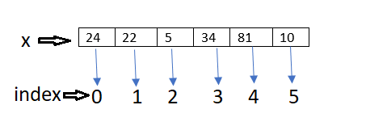

```python
x = [24, 22, 5, 34, 81, 10]
x
```

```
[24, 22, 5, 34, 81, 10]
```

Example: From the list `x` above, display the first element. See code below.

```python
x[0]
```

```
24
```

Example: From the list `x` above, display the third element. See code below.

```python
x[2]
```

```
5
```

Example: From the list `x` above, display the **last** element?

1. Click `+ Code`
2. Type `x = [24,22,5,34,81,10]`
3. Type `x[-1]`
4. Click `play` button

```python
x = [24,22,5,34,81,10]

x[-1]
```

```
10
```

**Note**: The index for the last element of a list is $-1$, the second from the last is $-2$, the third from the last is $-3$, etc

Example: Create a list named z using the following items: Monday, Tuesday, Wednesday, 4, 5, 6, and 7.0. Here, we have string, integer and float data types.

```python
z = ['Monday', 'Tuesday', 'Wednesday', 4, 5, 6, 7.0]
```

To display the whole list, enter its name or use the **print** function.

```python
print(z)
```

```
['Monday', 'Tuesday', 'Wednesday', 4, 5, 6, 7.0]
```

```python
z[0]      # the first item
```

```
'Monday'
```

```python
z[-1]    # the last item
```

```
7.0
```

```python
print(z[6])     # the 7 th item
print(z[-2])    # the second from the last
```

```
7.0
6
```

**Note**: To display multiple items of a Python list, use the slicing operator `[a:b]` from `a` to `b-1`. For example, `z[0:3]` will use index 0, 1, and 2. Notice 3 is not included.

Example: Display the first 3 elements of z.

```python
print(z[0:3])
```

```
['Monday', 'Tuesday', 'Wednesday']
```

**An Empty List**

A list that contains no elements is called an empty list; you can create one with empty brackets, []

`x = []`

```python
x=[]
x
```

```
[]
```

**Lists are mutable**

Elements of a list can be changed (replaced).

Example: From the list, `x=[10,20,30]`, replace the second element, `x[1]=20`, with the letter `a`.

```python
x = [10, 20, 30]
print(x)
x[1] = 'a'   # assign 'a' to the second element (replace 20 with 'a')
print(x)
```

```
[10, 20, 30]
[10, 'a', 30]
```

## 2.2 List Operations

Example: what is the frequency count for the element "Monday" for the list

```
x = ['Monday', 'Tuesday', 'Wednesday', 'Monday', 4, 5, 6, 4,
                  4, 7.0]
```

?

```python
x = ['Monday', 'Tuesday', 'Wednesday', 'Monday', 4, 5, 6, 4, 4, 7.0]
x.count('Monday')
```

```
2
```

Example: Sort the list `y = [10,14,20,15]`. Print the sorted list.

```python
y = [10,14,20,15]
y.sort()
y
```

```
[10, 14, 15, 20]
```

```python
y = [10,14,20,15]
y.reverse()   # revers order
y
```

```
[15, 20, 14, 10]
```

Example: Use the list `y = [10,14,20,15]` above to find the minimum item of the list.

```python
y = [10,14,20,15]
min(y)
```

```
10
```

Example: Use the list `y = [10,14,20,15]` above to find the maximum item of the list.

```python
y = [10,14,20,15]
max(y)
```

```
20
```

Example: Use the list `y = [10,14,20,15]` above to find the sum of all items in the list.

```python
y = [10,14,20,15]
sum(y)
```

```
59
```

Example: Use the list `y = [10,14,20,15]` above to find the length of the list. That is, how many items are there in the list?

```python
y = [10,14,20,15]
len(y)
```

```
4
```

Example: Write a Python program that displays the sum, minimum, maximum and length of the values of the elements in a given list, `x=[1,2,3,4,5,6,7,8,9]`

```python
x=[1,2,3,4,5,6,7,8,9]

print('the sum is:',sum(x))
print('the min is:',min(x))
print('the max is:',max(x))
print('the length is:',len(x))
```

```
the sum is: 45
the min is: 1
the max is: 9
the length is: 9
```

# 3. Python Syntax

"The syntax of a computer language is the set of rules that defines the combinations of symbols that are considered to be correctly structured statements or expressions in that language." Wikipedia

**Syntax Summary**

[Reference](https://www3.ntu.edu.sg/home/ehchua/programming/webprogramming/Python1_Basics.html#zz-2)

## 3.1 `if` Statements

[Watch demo video](https://youtu.be/V3sWrUXzvOg)

The `if` statement is used for decision making. If a specified condition is true, then a block of code is executed. If not true, the statement in the else if (`elif`) is checked and executed if true. If all are false, the process continues until the (`else`) statement.

Syntax

```
if condition1:        # this line ends with a colon :
   block statements   # this line(s) are indented
elif condition2:
   block statements
   ...
else:                 # no condition in this line
  block statements
```

Example: Given a number, for example 4, decide if it is positive or negative.

1. Click `+ Code` to add a code-cell
2. Type `a = 4`
3. Type `if a > 0:`
4. Type `print(' a is positive`)
5. Type `else:`
6. Type `a is negative or zero`
7. Click `play` button

```python
a = 4
if a > 0:
  print('a is positive')
else:
  print('a is negative or zero')
```

```
a is positive
```

**Note**: The if condition `a > 0` is either true or false. If true, the statement below the if condition is executed. If false the program goes to the `else` statement. In this case `a=4 > 0` is true and the statement `print('a is positive)` is executed.

### Python Comparison (Logical) Operators

A Boolean expression is an expression that is either true or false. The operator `==` compares two operands and produces `True` if they are equal and `False` otherwise.

| Name | Operator | Example | Result |
| --- | --- | --- | --- |
| Greater than | `>` | `5>6` | `False` |
| Greater than or Equal to | `>=` | `5>=4` | `True` |
| Less than | < | `5<4` | `False` |
| Less than or equal to | `<=` | `5<=5` | `True` |
| Equal | `==` | `5==6` | `False` |
| Not Equal | `!=` | `5!=6` | `True` |

Example: Change the number 4 to -4 in the above example. What is the result. See code below.

```python
a = -4
if a > 0:
  print('a is positive')
else:
  print('a is negative or zero')
```

```
a is negative or zero
```

Example: Given the numbers 2 and 3, decide if 2 is less than 3, greater than 3 or equal to 3.

```python
a = 2
b = 3
if a < b:                        # if statement ends with colon :
  print("2 is less than 3")      # block statement indented
elif a > b:
  print("2 is greater than 3")
else:
  print("2 is equal to 3")
```

[output not shown]

Example: Use `input()` function to ask the user for two integers and use these numbers in the `if` statement to decide if the first number is less, greater, or equal to the second number. This time we need to convert the string variable to decimal using the `float()` function.

```python
x = input("Enter first number :")
y = input("Enter second number :")

x = float(x)    # converts (casts) the default string value to an integer value
y = float(y)

if x < y:
  print("The first number is less than the second!")
elif x > y:
  print("The first number is greater than the second!")
else:
  print("They are equal!")
```

```
Enter first number :6
Enter second number :10
The first number is less than the second!
```

If Statement Flowchart

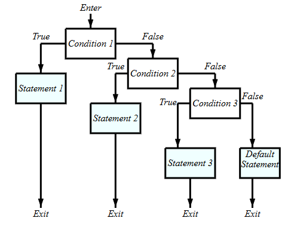

**Example**: The slope-intercept equation of a line with slope $m$ and $y$-intercept $b$ is given as $y=mx+b$ . if $m$ is positive, $y$ is increasing, if it is negative $y$ is decreasing and if it is zero $y$ is a constant. Write a program with slope m and use the `if` statement to decide if the line is increasing, decreasing or constant.

```python
m=3                       # the slope is selected to be 3

if m>0:
  print ("increasing")
elif m<0:
  print("decreasing")
else:
  print("constant")
```

```
increasing
```

Example: Write a Python program that asks a user to enter two numbers. Compute and display the sum of the two numbers. If the sum is greater than 10, compute and display the product of the two numbers. If the sum is less than 10 compute and display the product of the two numbers plus 5. Otherwise display the text 'the sum is 10'.

```python
x = input('enter the first number:')
y = input('enter the second number:')

x = float(x)
y = float(y)

sum1 = x + y        # 'sum' is a resrved key word in Python
print('the sum is',sum1)

if sum1 > 10:
  print('the product is',x*y)
elif sum1 < 10:
  print('the product plus 5 is',x*y+5)
```

```
enter the first number:5
enter the second number:6
the sum is 11.0
the product is 30.0
```

You can also use the built-in Python **input** function to read and return a line of string(text). Every time you run the code below, you will be asked to enter the slope of your choice. The function **int()** returns (converts) the value to an integer, whenever possible. [Reference to built-in Python functions](https://www.w3schools.com/python/python_ref_functions.asp)

```python
m=input("enter any integer number (your choice) for the slope m = ")
m = int(m)     # cast the input as integer

if m>0:                  # check if m>0
  print ("increasing")
elif m<0:                # check if m<0 if the if was False
  print("decreasing")
else:
  print("constant")
```

```
enter any integer number (your choice) for the slope m = -9
decreasing
```

## 3.2 Functions

[Watch demo video](https://youtu.be/mrccPSioPu4)

A function is a reusable piece of code. It is a block of code which only runs when it is called. You can pass data, known as arguments, into a function. A function can return data as a result. In Python a function is defined using the `def` keyword. This is similar to built-in functions such as `abs()` or `print()` but "your own".

Syntax

```
def func_name(arguments):
    block statements
    return result # optional
```

`def` is a **keyword** in Python. It is used to define a function.

Example: Use the formula $ C = (F-32)\frac{5}{9}$ to convert a temperature of $F=70$ degree Fahrenheit to $C$ degree Celsius. See code below.

```python
F = 70
C = (F-32)*5/9
C
```

```
21.11111111111111
```

Example: Make a Python that provides the equivalent degree Celsius for a given temperature in degree Fahrenheit. Use the formula $ C = (F-32)\frac{5}{9}$.

1. Click `+ Code` to add a code-cell
2. Type `def temp(F):`
3. Type indent `C = (F-32)*5/9`
4. Type indent `return C`
5. Click `play` button

**Note**: No output is displayed for function. It will display output when it is called with specific argument is provided. See example below.

```python
def temp(F):
  C = (F-32)*5/9
  return C
```

**Note**: the name of this function is chosen to be `temp`. There is one argument 'F'. The indented body of the function uses the formula to compute C. The return line displays the value of C.

Example: Use the function `temp(F)` above to convert a 100 degree Fahrenheit to Celsius.

1. Click `play` button on `temp` code cell above
2. Type `temp(100)`
3. Click `play` button

```python
temp(100)
```

```
37.77777777777778
```

Example: Use the `temp` function above to convert F = 0 to C. See code below.

```python
temp(0)
```

```
-17.77777777777778
```

Example: Use the quadratic formula to make a function for solving a quadratic equation of the form:

$ax^2+bx+c=0$

The solution(s):

If $b^2-4ac < 0$ No real solutions

If $b^2-4ac = 0$ There is one real solution, $x=-\frac{b}{2a}$

If $b^2-4ac > 0$ There are two real solutions

$x1 = \frac{-b-\sqrt{b^2-4ac}}{2a}$ and $x2 = \frac{-b+\sqrt{b^2-4ac}}{2a}$

See code below:

```python
# quadratic equation solver
def solvequad(a,b,c): # the name is solvequad and arguments a,b,c in that order
  a = float(a)              # converts or casts to float
  b = float(b)
  c = float(c)
  if b**2-4*a*c < 0:
    return print("No real solutions")
  elif b**2-4*a*c == 0:
    x = -b/(2*a)
    return print("The solution is", x)
  else:
    x1 = (-b-(b**2-4*a*c)**.5)/(2*a)
    x2 = (-b+(b**2-4*a*c)**.5)/(2*a)
    return print("The solutions are: ",x1," and ",x2)
```

Example: Solve $x^2-4=0$,

Here a=1, b=0, c=-4 because $1x^2+0x+(-4)=0$

```python
solvequad(1,0,-4)     # run the solvequad function above first
```

```
The solutions are:  -2.0  and  2.0
```

Alternatively, you can pass `a=1,b=0,c=-4` to the function as follows:

```python
solvequad(a=1,b=0,c=-4)     # run the solvequad function above first
```

```
The solutions are:  -2.0  and  2.0
```

Run the function `solvequad(a,b,c)` before you call `solvequad(1,0,-4)`.

Example: Solve $3x^2+5x-7$

Here $a=3,b=5,c=-7$

```python
solvequad(3,5,-7)
```

```
The solutions are:  -2.5733844181517584  and  0.9067177514850918
```

## 3.3 Syntax Errors

[Watch demo video](https://youtu.be/i16E0LUCGGg)

Incorrectly written command or instruction will cause a failure in execution. For example, **indentation** (any length) and `:` (colon) are part of the syntax for the `if` statement. In the program below, colon `:` is missing in the first line.

Example: In the code below, colon is missing in the first line of the if condition.

```python
if 2 < 3                       # colon : is missing
  print("It is less than!")
elif 2 > 3:
  print("It is greater!")
else:
  print("Equal!")
```

```
  File "<ipython-input-102-e5ff2ebb180c>", line 1
    if 2 < 3                       # colon : is missing
                                                       ^
SyntaxError: invalid syntax
```

Example: In the code below, indentation is missing in the block statement of the if condition in line 2.

```python
if 2 < 3:
print("It is less than!")   # block statement needs indentation
elif 2 > 3:
  print("It is greater!")
else:
  print("Equal!")
```

```
  File "<ipython-input-103-3c294b21dd46>", line 2
    print("It is less than!")   # block statement needs indentation
        ^
IndentationError: expected an indented block
```

Example: When an undeclared variable is used in a statement, it causes error messages. In the code below, `slope` was not defined ahead of the `if` condition.

```python
if slope > 0:                # slope is not defined can not be compared to zero
  print('increasing')
else:
  print('decreasing')
```

```
---------------------------------------------------------------------------
NameError                                 Traceback (most recent call last)
<ipython-input-105-942dc7b20bf4> in <module>()
----> 1 if slope > 0:                # slope is not defined can not be compared to zero
      2   print('increasing')
      3 else:
      4   print('decreasing')

NameError: name 'slope' is not defined
```

# 4. Python Loops

A loop statement allows us to execute statement(s) multiple times. Two types of loops:

1. The iterative `for` loop
2. The conditional `while` loop

## 4.1 The `for` Loop

[Watch demo video](https://youtu.be/aJUlLZfjVbQ)

The `for` loop can be used to iterate over a sequence such as a list or other iterable objects.

Syntax:

```
 for i in sequence_name:      # i will take each value of sequence_name
    block statements
```

For Loop Flowchart

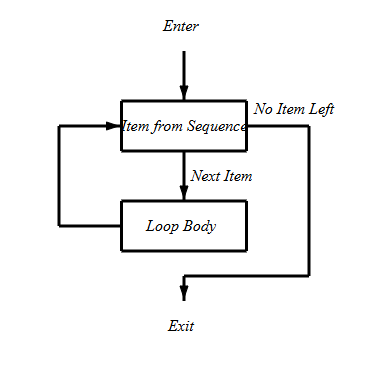

The flow of execution for a `for` statement:

1. Take the first element in the list
2. execute the block statement
3. Go back to step 1
4. Repeat step 1 to 3 until the last element of the list reached

Example: print the values of each element in the list `x=[5, 10, 5, 4]`.

1. Click `+ Code` to add a code-cell
2. Type `x = [5, 10, 5, 4]`
3. Type `for v in x:`
4. Type indented `print(v)`

```python
x = [5, 10, 5, 4]
for v in x:
	print(v)
```

```
5
10
5
4
```

**Note**: When the program reaches the second line and encounters `for`, it uses `v` to store the first element in `x`. In the third line, it will print the current value of v. Then it will go back to the second line and use `v` to store the second element in `x` and prints this updated value of `v`. This pattern repeats till all elements in `x` are reached.

[Watch demo video](https://youtu.be/5WvWTbweFDo)

Example: Given a list of integers, use the `for` loop to add all values in a list. Same as `sum(x)` from list operators.

```python
x = [5, 10, 5, 4]
sum1 = 0
for i in x:
	sum1 = sum1 + i
print("The sum is", sum1)
```

```
The sum is 24
```

**Note**: In the above code, `i` is the variable that takes the value of the elements inside the `x` list on each iteration. The `for` loop continues until the last element in the list is reached. The body of `for` loop is separated from the rest of the code using **indentation**.

**Note**: The flow of execution:

Begin

- `x = [5, 10, 5, 4]` (line 1)
- `sum1 = 0` (line 2)

Enter `for` loop

- `i=x[0]=5` (line 4)
- `sum1 = sum1 + i = 0 + 5 = 5`. (line 5)

Back to the `for` loop

- `i=x[1]=10` (line 4)
- `sum1 = sum1 + i = 5 + 10 = 15` (line 5)

Back to the `for` loop

- `i=x[2]=5` (line 4)
- `sum1 = sum1 + i = 15 + 5 = 20` (line 5)

Back to the `for` loop

- `i=x[3]=4` (line 4)
- `sum1 = sum1 + i = 20 + 4 = 24` (line 5)

Back to the `for` loop `i=x[4]` no element left in the list

- Exit the `for` loop

Go to line 6

- `print("The sum is", sum1)`.

This could also be done using the `sum(x)` list operator as follows:

```python
x = [5,10,5,4]
sum(x)
```

```
24
```

Example: Given a `list` of numbers, find its average. The average is the sum of all the numbers divided by size of the list.

```python
x = [2.3,3.5,4,2.6,3.1,1.9]
sum1 = 0
for i in x:
  sum1 = sum1 + i
average = sum1/len(x)
print("the average is ", average)
```

```
the average is  2.9
```

**Note**: The total `sum1` is the same as the code above. After the `for` loop in line 4, `average=sum1/len(x)`. `len(x)` is the size or number of elements in `x`.

Example: The ages of current (as of 2020) US Senators are given below. Write a Python program that displays the number of Senators who are older than 65 years.

```
81,81,80,80,80,80,78,78,78,77,77,75,75,74,74,74,73,72,72,71,71,71,71,70,70,
                  70,70,68,68,68,68,68,67,67,67,66,66,65,65,65,65,64,64,64,64,64,64,63,
                  63,
                  63,63,62,62,62,62,62,61,61,61,60,60,59,59,59,59,59,59,59,59,58,58,57,
                  57,56,56,55,54,54,54,54,54,53,53,52,52,52,52,52,51,50,49,48,46,45,44,43,43,
                  43,42,41
```

```python
age = [81,81,80,80,80,80,78,78,78,77,77,75,75,74,74,74,73,72,72,71,71,71,71,70,
    70,70,70,68,68,68,68,68,67,67,67,66,66,65,65,65,65,64,64,64,64,64,64,63,63,
        63,63,62,62,62,62,62,61,61,61,60,60,59,59,59,59,59,59,59,59,58,58,57,57,
        56,56,55,54,54,54,54,54,53,53,52,52,52,52,52,51,50,49,48,46,45,44,43,43,
        43,42,41]

count = 0
for i in age:
  if i > 65:
    count = count + 1
print(count)
print('Of the',len(age),'Senators,', count,'are over 65 years old')
```

```
37
Of the 100 Senators, 37 are over 65 years old
```

**Note**: `age` and `count` are defined first. In the `for` statement `i` takes the first element of `age` and checks if it is greater than 65. If true `count = 0 + 1` if not true, it will go back to the `for` statement and `i` takes the second element in `age`. The pattern continues till the last element in `age`.

While Loop Flowchart

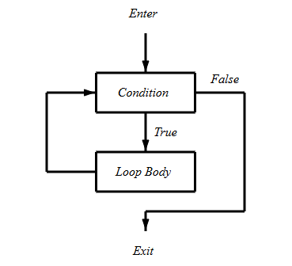

Syntax

```
while condition:
  block statements
```

The flow of execution for a `while` statement:

1. Evaluate the condition, yielding True or False.
2. If the condition is false, exit the while statement and continue execution at the next statement.
3. If the condition is true, execute the body and then go back to step 1.

Example: Print the first 5 positive integers: 1, 2, 3, 4, and 5.

```python
i = 0
while i < 5:
   i = i + 1
   print(i)
```

```
1
2
3
4
5
```

**Note**: In the above code, the flow of execution is:

Begin in line 1

- `i = 0` before the loop

Enter `while` loop

- `i = 0 < 5` is `True` (line 2)
- `i = i + 1 = 0 + 1 = 1` (line 3)
- print `i = 1` (line 4)

Back to the `while` loop

- `i = 1 < 5` is `True`, (line 2)
- `i = i + 1 = 1 + 1 = 2` (line 3)
- print `i = 2` (line 4)

Back to the `while` loop

- `i = 2 < 5` is `True` (line 2)
- `i = i + 1 = 2 + 1 = 3` (line 3)
- print `i = 3` (line 4)

Back to the `while` loop

- `i = 3 < 5` is `True` (line 2)
- `i = i + 1 = 3 + 1 = 4` (line 3)
- print `i = 4` (line 4)

Back to the `while` loop

- `i = 4 < 5` is `True` (line 2)
- `i = i + 1 = 4 + 1 = 5` (line 3)
- print `i = 5`(line 4)

Back to the `while` statement.

- `i = 5 < 5` is `False` Exit the loop

Example: Find the sum of the first 5 positive integers.

```python
i = 0
sum1 = 0
while i < 5:
   i = i + 1
   sum1 = sum1 + i

print("Total sum:",sum1)
```

```
Total sum: 15
```

In the above code:

- `i = 0` and `sum1 = 0` before the loop
- `i = 0 < 5` is true (1st loop)

  ```
   i = i + 1 = 0 + 1 = 1 and sum1 = sum1 + i = 0 + 1 = 1
  ```

- `i = 1 < 5` is true (2nd loop) i = i + 1 = 1 + 1 = 2 and sum1 = sum1 + i = 1 + 2 = 3
- `i = 2 < 5` is true (2nd loop) i = i + 1 = 2 + 1 = 3 and sum1 = sum1 + i = 3 + 3 = 6
- `i = 3 < 5` is true (3rd loop) i = i + 1 = 3 + 1 = 4 and sum1 = sum1 + i = 6 + 4 = 10
- `i = 4 < 5` is true (4th loop) i = i + 1 = 4 + 1 = 5 and sum1 = sum1 + i = 10 + 5 = 15
- `i = 5 < 5` is false exit loop

print sum = 15 (last value of sum)

**Note**: Fibonacci Numbers: `1,1,2,3,5,8,13,21,34,55,89,144,...` The first two are 1 and 1. The rest are found by adding the two preceding numbers. The list can continue indefinitely.

Example: Write a Python program that lists a user given number of Fibonacci numbers.

```python
n = input("How many Fibonacci numbers do you want to list? ")

n = int(n)  # convert the default string to integer

i = 0   # initial counter
a = 1   # first number is 1
b = 1   # second number is 1

if n <= 0:
  print("Enter a positive integer")
if n == 1:
  print(a)
else:
 while i < n:   # repeat action while i < n is true
  print(a)     # print the first number
  i = i + 1    # increase i by 1
  c = a + b    # add the previous two numbers and place it in c
  a = b        # update the last two numbers
  b = c        # update the last two numbers
```

```
How many Fibonacci numbers do you want to list?10
1
1
2
3
5
8
13
21
34
55
```

# 5. Frequency Distributions and Graphs

In statistics, dataset can be summarized in tabular or graphical displays. A frequency distribution can be described as a table that displays several value(s) or categories with their associated frequencies or counts.

## 5.1 Frequency Distribution

For a unique count of each data value in a dataset use the syntax:

```
import numpy as np
x = [x1,x2,x3,...]
np.unique(x,return_counts=True)
```

**Note**: Dataset will be entered in Python list as `x = [x1,x2,x3,...]`

Example: The dataset below is the waiting time, in minutes, of customers at a fast food restaurant. Write a program to construct a frequency of unique values.

```
5, 3, 4, 1, 5, 3, 5, 2, 3, 2, 5, 4, 4, 6, 4, 3, 4, 1, 2,
                  5
```

[Watch demo video](https://youtu.be/hCihG4VmFGk)

1. Click `+ Code`
2. Type `import numpy as np`
3. Type

   ```
   x = [5, 3, 4, 1, 5, 3, 5, 2, 3, 2, 5, 4, 4, 6, 4, 3, 4, 1,
                       2, 5]
   ```

4. Type `np.unique(x,return_counts=True)`
5. Click `play` button
6. Two array output is displayed - unique value and frequency

```python
import numpy as np
x = [5, 3, 4, 1, 5, 3, 5, 2, 3, 2, 5, 4, 4, 6, 4, 3, 4, 1, 2, 5]
np.unique(x,return_counts=True)
```

```
(array([1, 2, 3, 4, 5, 6]), array([2, 3, 4, 5, 5, 1]))
```

Interpretation: In the above output, the first array is the list of unique elements and the second array is counts (frequencies) for each unique element. For example, the value 1 from the first array has a frequency of 2 from the second array, etc.

| value | frequency |
| --- | --- |
| 1 | 2 |
| 2 | 3 |
| 3 | 4 |
| 4 | 5 |
| 5 | 5 |
| 6 | 1 |

**Note**: We will use the variable name `x` to store the data values in a Python List.

**Example**: 20 students were asked if they were registered to vote. Their responses are listed below. Write a program to construct a frequency table.

```
NO, NO, YES, YES, NO, YES, NO, NO, YES, NO, YES, NO, NO, YES,
                  YES, YES, YES, NO, YES, YES
```

[Watch demo video](https://youtu.be/JYgEzk4LSTQ)

```python
import numpy as np
x = ['NO', 'NO', 'YES', 'YES', 'NO', 'YES', 'NO', 'NO', 'YES', 'NO',
             'YES', 'NO', 'NO', 'YES', 'YES', 'YES', 'YES', 'NO', 'YES', 'YES']
np.unique(x,return_counts=True)
```

```
(array(['NO', 'YES'], dtype='<U3'), array([ 9, 11]))
```

Interpretation: from the above output:

| value | frequency |
| --- | --- |
| NO | 9 |
| YES | 11 |

For making a frequency distribution with k classes (bins), use the following code:

```
import numpy as np
x = [x1,x2,x3,...]
np.histogram(x,bins=k,density=False)
```

```
33, 42, 49, 49, 53, 55, 55, 61, 63, 67, 68, 68, 69, 69, 72,
                  73, 74,78, 80, 83, 88, 88, 88, 90, 92, 94, 94, 94, 94, 96,
                  100
```

[Watch demo video](https://youtu.be/_TaA9uA-E0U)

1. Click `+ Code`
2. Type `import numpy as np`
3. Type

   ```
   x = [33, 42, 49, 49, 53, 55, 55, 61, 63, 67, 68, 68, 69,
                       69, 72, 73, 74, 78, 80, 83, 88, 88, 88, 90, 92, 94, 94, 94,
                       94, 96, 100]
   ```

4. `np.histogram(x, bins=5,density=False)`
5. Two array output - frequencies and classes

```python
import numpy as np
x = [33, 42, 49, 49, 53, 55, 55, 61, 63, 67, 68, 68, 69, 69, 72, 73, 74,
             78, 80, 83, 88, 88, 88, 90, 92, 94, 94, 94, 94, 96, 100]
np.histogram(x, bins=5,density=False)
```

```
(array([ 2,  5,  9,  4, 11]),
 array([ 33. ,  46.4,  59.8,  73.2,  86.6, 100. ]))
```

Interpretation from the above output:

| classes | freq |
| --- | --- |
| 33 - 46.4 | 2 |
| 46.4 - 59.8 | 5 |
| 59.8 - 73.2 | 9 |
| 73.2 - 86.6 | 4 |
| 86.6 - 100 | 11 |

key: `33-46.4 is [33,46.4)` or $33 \le x < 46.4$

```
33, 42, 49, 49, 53, 55, 55, 61, 63, 67, 68, 68, 69, 69, 72,
                  73, 74,78, 80, 83, 88, 88, 88, 90, 92, 94, 94, 94, 94, 96,
                  100
```

1. Click `+ Code`
2. Type `import numpy as np`
3. Type

   ```
   x = [33, 42, 49, 49, 53, 55, 55, 61, 63, 67, 68, 68, 69,
                       69, 72, 73, 74, 78, 80, 83, 88, 88, 88, 90, 92, 94, 94, 94,
                       94, 96, 100]
   ```

4. Type

   ```
   freq, class_limit = np.histogram(x,
                       bins=5,density=False)
   ```

5. Type `print(class_limit)`
6. Type `print(freq)`

```python
import numpy as np
x = [33, 42, 49, 49, 53, 55, 55, 61, 63, 67, 68, 68, 69, 69, 72, 73, 74,
             78, 80, 83, 88, 88, 88, 90, 92, 94, 94, 94, 94, 96, 100]
freq, class_limit = np.histogram(x, bins=5,density=False)
print(class_limit)
print(freq)
```

```
[ 33.   46.4  59.8  73.2  86.6 100. ]
[ 2  5  9  4 11]
```

Interpretation from the above output:

| classes | freq |
| --- | --- |
| 33 - 46.4 | 2 |
| 46.4 - 59.8 | 5 |
| 59.8 - 73.2 | 9 |
| 73.2 - 86.6 | 4 |
| 86.6 - 100 | 11 |

key: `33-46.4 is [33,46.4)` or $33 \le x < 46.4$

**Example**: Use the US Senators age (as of 2021) dataset given below to construct a relative frequency distribution with 5 bins (classes).

`81,81,80,80,80,80,78,78,78,77,77,75,75,74,74,74,73,72,72,71,71,71,71,70,70,70,70,68,68,68,68,68,67,67,67,66,66,65,65,65,65,64,64,64,64,64,64,63,63,63,63,62,62,62,62,62,61,61,61,60,60,59,59,59,59,59,59,59,59,58,58,57,57,56,56,55,54,54,54,54,54,53,53,52,52,52,52,52,51,50,49,48,46,45,44,43,43,43,42,41`

```python
import numpy as np
x = [81,81,80,80,80,80,78,78,78,77,77,75,75,74,74,74,73,72,72,71,71,71,
             71,70,70, 70,70,68,68,68,68,68,67,67,67,66,66,65,65,65,65,64,64,64,
             64,64,64,63,63,63,63,62,62,62,62,62,61,61,61,60,60,59,59,59,59,59,
             59,59,59,58,58,57,57,56,56,55,54,54,54,54,54,53,53,52,52,52,52,52,
             51,50,49,48,46,45,44,43,43,43,42,41]
freq, bin_edges = np.histogram(x, bins=5,density=True)
print(bin_edges)
print(freq)
```

```
[41. 49. 57. 65. 73. 81.]
[0.01125 0.0225  0.04    0.03    0.02125]
```

Interpretation from the above output:

[output not shown]

key: `41 - 49 is [41,49)`

## 5.2 The Matplotlib Library

`Matplotlib.pyplot` is a graph plotting software library in python that serves as a visualization utility. `matplotlib.pyplot` is typically imported with the alias `plt`.

`Matplotlib.pyplot` Functions

| Function | Description |
| --- | --- |
| `plt.bar(x,y)` | Bar Graph |
| `plt.pie(y,labels=x)` | Pie Chart |
| `plt.hist(x,bins=k)` | Histogram with k classes |
| `plt.scatter(x,y)` | Scatter Plot |
| `plt.suptitle("Main Title")` | Main Title |
| `plt.xlabel("Horizontal Title")` | Horizontal Label |
| `plt.ylabel("Vertical Title")` | Vertical Label |

## 5.3 Bar Graphs and Pie Charts

Given frequency tables with two columns: categories/values and frequencies:

Syntax for bar graph

```
import matplotlib.pyplot as plt
value = [x1,x2,...]
freq = [y1,y2,...]
plt.bar(value,freq)
```

Syntax for pie chart

```
import matplotlib.pyplot as plt
value = [x1,x2,...]
freq = [y1,y2,...]
plt.pie(freq, labels=value,autopct='%1.1f%%' )
```

Example: 20 students were asked if they were registered to vote. Their responses are given below. Plot a bar graph.

| vote | freq |
| --- | --- |
| Yes | 11 |
| No | 9 |

[Watch demo video](https://youtu.be/QsYU4o1yLJg)

1. Click `+ Code`
2. Type `import matplotlib.pyplot as plt`
3. Type `v = ['Yes','No']`
4. Type `f = [11,9]`
5. Type `plt.bar(v,f)`
6. Click `play` button
7. Right click image to save it to your device

```
<BarContainer object of 2 artists>
```

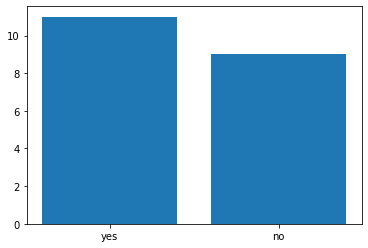

```python
import matplotlib.pyplot as plt
v = ['yes','no']
f = [11,9]
plt.bar(v,f)
```

Example: 20 students were asked if they were registered to vote. Their responses are given below. Plot a pie chart (percent).

| vote | freq |
| --- | --- |
| Yes | 11 |
| No | 9 |

[Watch demo video](https://youtu.be/N0kg36QPWzQ)

**Note**: `autopct='%1.1f%%'` changes the frequency to percent rounded to one decimal place, and adds the percent sign %.

[output not shown]

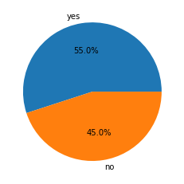

```python
import matplotlib.pyplot as plt
v = ['yes','no']
f = [11,9]
plt.pie(f,labels=v,autopct='%1.1f%%')
```

Example: 20 students were asked if they were registered to vote. Their responses are given below. Plot a bar graph.

| vote | freq |
| --- | --- |
| Yes | 11 |
| No | 9 |

Add title, vertical and horizontal labels.

1. Click `+ Code`
2. Type `import matplotlib.pyplot as plt`
3. Type `v = ['Yes','No']`
4. Type `f = [11,9]`
5. Type `plt.bar(v,f)`
6. Type `plt.suptitle("Voter Registation")`
7. Type `plt.xlabel("Registration")`
8. Type `plt.ylabel("Frequency")`
9. Click `play` button

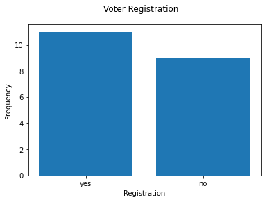

```python
import matplotlib.pyplot as plt
v = ['yes','no']
f = [11,9]
plt.bar(v,f)
plt.suptitle("Voter Registration")
plt.xlabel("Registration")
plt.ylabel("Frequency")
```

Example: The frequency distribution below is the waiting time, in minutes, of 20 customers at a fast food restaurant.

| Waiting_time | Frequency |
| --- | --- |
| 1 | 2 |
| 2 | 3 |
| 3 | 4 |
| 4 | 5 |
| 5 | 5 |
| 6 | 1 |

Plot a bar graph and a pie chart.

**Note**: First the data values in the two columns are entered separately using Python lists: `waiting_time` and `frequency`.

1. Click `+ Code`
2. Type `import matplotlib.pyplot as plt`
3. Type `waiting_time = [1,2,3,4,5,6]`
4. Type `frequency = [2,3,4,5,5,1]`
5. Type `plt.bar(waiting_time,frequency)`
6. Type `plt.xlabel("Waiting Time")`
7. Type `plt.ylabel("Frequency")`
8. Click `play` button

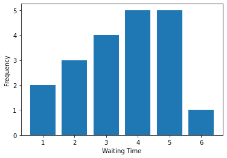

```python
import matplotlib.pyplot as plt

waiting_time = [1,2,3,4,5,6]
frequency = [2,3,4,5,5,1]

plt.bar(waiting_time,frequency)

plt.xlabel("Waiting Time")
plt.ylabel("Frequency")
```

Example: The frequency distribution below is the waiting time, in minutes, of 20 customers at a fast food restaurant.

| Waiting_time | Frequency |
| --- | --- |
| 1 | 2 |
| 2 | 3 |
| 3 | 4 |
| 4 | 5 |
| 5 | 5 |
| 6 | 1 |

Graph a Pie Chart

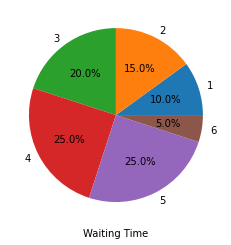

```python
import matplotlib.pyplot as plt

waiting_time = [1,2,3,4,5,6]
frequency = [2,3,4,5,5,1]
plt.pie(frequency, labels=waiting_time,autopct='%1.1f%%')
plt.xlabel("Waiting Time")
```

## 5.4 Histogram, Polygon and Ogive

A histogram uses connected bars to represent the frequency distribution of a continuous dataset.

Syntax for n bins(classes)

```
import matplotlib.pyplot as plt
plt.hist(x,bins=n,ec='k')
```

```
33, 42, 49, 49, 53, 55, 55, 61, 63, 67, 68, 68, 69, 69, 72,
                  73, 74,78, 80, 83, 88, 88, 88, 90, 92, 94, 94, 94, 94, 96,
                  100
```

[Deom Video Link](https://youtu.be/L8d6GKv-95Y)

1. Click `+ Code`
2. Type `import matplotlib.pyplot as plt`
3. Type

   ```
   x = [33, 42, 49, 49, 53, 55, 55, 61, 63, 67, 68, 68, 69,
                       69, 72, 73, 74,78, 80, 83, 88, 88, 88, 90, 92, 94, 94, 94,
                       94, 96, 100]
   ```

4. Type `plt.hist(x,bins=5,ec='k')`
5. Click `play` button

Note: `ec='k'` adds solid black lines to the bars.

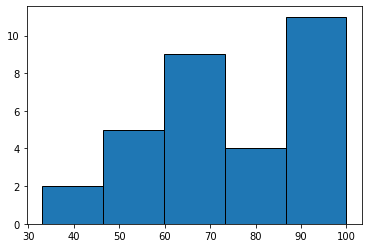

```python
import matplotlib.pyplot as plt
x = [33, 42, 49, 49, 53, 55, 55, 61, 63, 67, 68, 68, 69, 69, 72, 73, 74,78, 80,
     83, 88, 88, 88, 90, 92, 94, 94, 94, 94, 96, 100]
plt.hist(x,bins=5,ec='k')
```

```
33, 42, 49, 49, 53, 55, 55, 61, 63, 67, 68, 68, 69, 69, 72,
                  73, 74,78, 80, 83, 88, 88, 88, 90, 92, 94, 94, 94, 94, 96,
                  100
```

1. Click `+ Code`
2. Type `import matplotlib.pyplot as plt`
3. Type

   ```
   x = [33, 42, 49, 49, 53, 55, 55, 61, 63, 67, 68, 68, 69,
                       69, 72, 73, 74,78, 80, 83, 88, 88, 88, 90, 92, 94, 94, 94,
                       94, 96, 100]
   ```

4. Type `(freq, class_limit, patches) = plt.hist(x,bins=5)`
5. Type `plt.xticks(class_limit)`
6. Click `play` button

[output not shown]

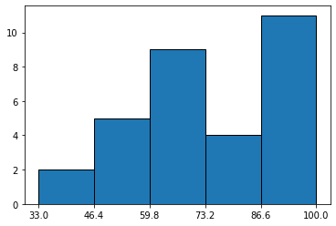

```python
import matplotlib.pyplot as plt
x = [33, 42, 49, 49, 53, 55, 55, 61, 63, 67, 68, 68, 69, 69, 72, 73, 74,
           78, 80, 83, 88, 88, 88, 90, 92, 94, 94, 94, 94, 96, 100]

(freq,class_limit,patches) = plt.hist(x,bins=5,ec='k')
plt.xticks(class_limit)
```

Example: Histograms from raw data

Use the US Senators age data given below and write a program to:

1. Make a histogram with 5 bins (classes) and age range of 40 to 90
2. Display the frequencies and bins(classes)
3. Add titles and labels

`81,81,80,80,80,80,78,78,78,77,77,75,75,74,74,74,73,72,72,71,71,71,71,70,70,70,70,68,68,68,68,68,67,67,67,66,66,65,65,65,65,64,64,64,64,64,64,63,63,63,63,62,62,62,62,62,61,61,61,60,60,59,59,59,59,59,59,59,59,58,58,57,57,56,56,55,54,54,54,54,54,53,53,52,52,52,52,52,51,50,49,48,46,45,44,43,43,43,42,41`

```
bins [40. 50. 60. 70. 80. 90.]
freq [10. 29. 34. 21.  6.]
```

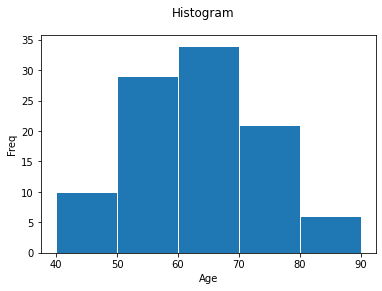

```python
import matplotlib.pyplot as plt

age = [81,81,80,80,80,80,78,78,78,77,77,75,75,74,74,74,73,72,72,71,71,71,71,70,70,
        70,70,68,68,68,68,68,67,67,67,66,66,65,65,65,65,64,64,64,64,64,64,63,63,
        63,63,62,62,62,62,62,61,61,61,60,60,59,59,59,59,59,59,59,59,58,58,57,57,
        56,56,55,54,54,54,54,54,53,53,52,52,52,52,52,51,50,49,48,46,45,44,43,43,
        43,42,41]

(freq, bins, patches) = plt.hist(age,bins=5,edgecolor='white', range=[40,90])

plt.suptitle("Histogram")
plt.xlabel("Age")
plt.ylabel("Freq")

print("bins", bins)
print("freq",freq)
```

Interpretation from the above output for bins and frequencies:

| bins | frequency |
| --- | --- |
| 40-50 | 10 |
| 50-60 | 29 |
| 60-70 | 34 |
| 70-80 | 21 |
| 80-90 | 6 |

### Frequency Polygon

A frequency polygon is a line graph connecting midpoints of each class/bin.

Example: Use the above example (Senators age) to construct a frequency *polygon*.

We will use the function below to construct a polygon. The arguments (input) to the function are the data values, x, and number of classes(bins), n.

### Python Functions

A function is a block of code which only runs when it is called. You can pass data, known as **arguments**, into a function. A function can return data as a result. In Python a function is defined using the `def` keyword.

Syntax

```
def func_name(data):
    statement(s)
    return result  # optional
```

When the function `func_name(x)` is called it will return `result`.

To graph a frequency polygon, use the function `polygon(x,n)` given below. `x` is the dataset list and `n` is the number of classes/bins.

```python
def polygon(x,n):
  import matplotlib.pyplot as plt
  import numpy as np

  freq, bins, edges = plt.hist(x,bins=n,ec="k",range=[min(x),max(x)+1])
  plt.title("Frequency Polygon")
  plt.xlabel('Midpoint data values')
  plt.ylabel('Frequency')

  a1=bins[0]-(bins[1]-bins[0])
  a2=bins[-1]+(bins[1]-bins[0])
  bin1=np.insert(bins,[0],a1)
  bin1=np.append(bin1,a2)

  freq,edges,_=plt.hist(x,bins=bin1,ec='k', facecolor='blue', range=[min(x),max(x)+1])
  midpoints=0.5*(edges[1:]+edges[:-1])
  plt.plot(midpoints,freq)
#  plt.xticks(bin1)
  plt.xticks(midpoints)
  plt.show()
```

Example: Use the the `polygon(x,n)` function above to plot a frequency polygon of the US Senators age data given below with 5 bins(classes).

`81,81,80,80,80,80,78,78,78,77,77,75,75,74,74,74,73,72,72,71,71,71,71,70,70,70,70,68,68,68,68,68,67,67,67,66,66,65,65,65,65,64,64,64,64,64,64,63,63,63,63,62,62,62,62,62,61,61,61,60,60,59,59,59,59,59,59,59,59,58,58,57,57,56,56,55,54,54,54,54,54,53,53,52,52,52,52,52,51,50,49,48,46,45,44,43,43,43,42,41`

[Watch demo video](https://youtu.be/tODhCXiiZ3U)

1. Click `play` button on the above code `def polygon(x,n)`
2. Type

   ```
   x =
                       [81,81,80,80,80,80,78,78,78,77,77,75,75,74,74,74,73,72,72,71,71,71,71,70,70,70,70,68,68,68,68,68,67,67,67,66,66,65,65,65,65,64,64,64,64,64,64,63,63,63,63,62,62,62,62,62,61,61,61,60,60,59,59,59,59,59,59,59,59,58,58,57,57,56,56,55,54,54,54,54,54,53,53,52,52,52,52,52,51,50,49,48,46,45,44,43,43,43,42,41]
   ```

3. Type `polygon(x,5)`
4. Click on `play` button

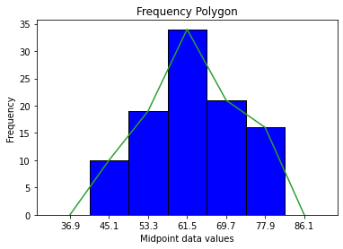

```python
x = [81,81,80,80,80,80,78,78,78,77,77,75,75,74,74,74,73,72,72,71,71,71,71,70,70,
        70,70,68,68,68,68,68,67,67,67,66,66,65,65,65,65,64,64,64,64,64,64,63,63,
        63,63,62,62,62,62,62,61,61,61,60,60,59,59,59,59,59,59,59,59,58,58,57,57,
        56,56,55,54,54,54,54,54,53,53,52,52,52,52,52,51,50,49,48,46,45,44,43,43,
        43,42,41]
polygon(x,5)
```

### Ogive

Ogive is a line graph that displays cumulative frequency of each (upper) class. To graph an ogive , use the function `ogive(x,n)` given below. `x` is the dataset list and `n` is the number of classes/bins.

```python
def ogive(x,n):
  import matplotlib.pyplot as plt
  import numpy as np

  freq, bins, edges = plt.hist(x,bins=n,ec="k",range=[min(x),max(x)+1])
  plt.title("Ogive")
  plt.xlabel('data values')
  plt.ylabel('Cumulative frequency')

  a1=bins[0]-(bins[1]-bins[0])
  a2=bins[-1]+(bins[1]-bins[0])
  bin1=np.insert(bins,[0],a1)
  bin1=np.append(bin1,a2)

  freq,edges,_=plt.hist(x,bins=bin1,ec='k', facecolor='blue', range=[min(x),max(x)+1])

  ogive1 = edges[:-1]
  cumfreq = np.cumsum(freq)
  plt.plot(ogive1,cumfreq)
  plt.xticks(bin1)
  plt.show()
```

Example: Use the `ogive(x,n)` function above to plot an ogive of the US Senators age data given below with 5 bins(classes).

`81,81,80,80,80,80,78,78,78,77,77,75,75,74,74,74,73,72,72,71,71,71,71,70,70,70,70,68,68,68,68,68,67,67,67,66,66,65,65,65,65,64,64,64,64,64,64,63,63,63,63,62,62,62,62,62,61,61,61,60,60,59,59,59,59,59,59,59,59,58,58,57,57,56,56,55,54,54,54,54,54,53,53,52,52,52,52,52,51,50,49,48,46,45,44,43,43,43,42,41`

[Watch demo video](https://youtu.be/DqXv-D5-3S4)

1. Click `play` button on the above code `def ogive(x,n)`
2. Type

   ```
   x =
                       [81,81,80,80,80,80,78,78,78,77,77,75,75,74,74,74,73,72,72,71,71,71,71,70,70,70,70,68,68,68,68,68,67,67,67,66,66,65,65,65,65,64,64,64,64,64,64,63,63,63,63,62,62,62,62,62,61,61,61,60,60,59,59,59,59,59,59,59,59,58,58,57,57,56,56,55,54,54,54,54,54,53,53,52,52,52,52,52,51,50,49,48,46,45,44,43,43,43,42,41]
   ```

3. Type `ogive(x,5)`
4. Click on `play` button

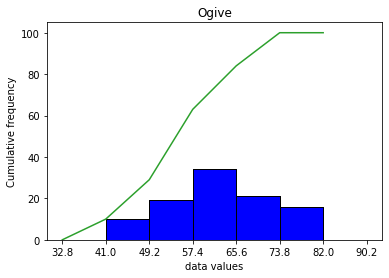

```python
x = [81,81,80,80,80,80,78,78,78,77,77,75,75,74,74,74,73,72,72,71,71,71,71,70,70,
        70,70,68,68,68,68,68,67,67,67,66,66,65,65,65,65,64,64,64,64,64,64,63,63,
        63,63,62,62,62,62,62,61,61,61,60,60,59,59,59,59,59,59,59,59,58,58,57,57,
        56,56,55,54,54,54,54,54,53,53,52,52,52,52,52,51,50,49,48,46,45,44,43,43,
        43,42,41]
ogive(x,5)
```

## 5.5 Dot Plots

Dot plot is like bar graph with dots instead of bars. To graph an dot plot , use the function `dotplot(x)` given below. `x` is the dataset list.

```python
# dotplot by Patrick FitzGerald
def dotplots(x, x_label="Data Values"):
         # takes a x and x_label (by default it is Data Values)

 import numpy as np
 import matplotlib.pyplot as plt

 data = np.array(x)   # convert to array
 values, counts = np.unique(data, return_counts=True)

# dot plot with appropriate figure size and y-axis limits
 fig, ax = plt.subplots(figsize=(6, 2.25))
 for value, count in zip(values, counts):
    ax.plot([value]*count, list(range(count)), 'co', ms=10, linestyle='')
 for spine in ['top', 'right', 'left']:
    ax.spines[spine].set_visible(False)
 ax.yaxis.set_visible(False)
 ax.set_ylim(-1, max(counts))
 ax.set_xticks(range(min(values), max(values)+1))
 ax.tick_params(axis='x', length=0, pad=8, labelsize=12)

 plt.suptitle("Dot Plot")
 plt.ylabel("frequency")
 plt.xlabel(x_label)

 return plt.show()
```

Example: Use the `dotplot(x)` function above to plot a dot plot of the dataset given below.

`1, 2, 2, 3, 3, 3, 3, 4, 7, 9`

[Watch demo video](https://youtu.be/ZF8BB080wFM)

1. Click `play` button on the code above `def dotplot(x)`
2. Type `x = [1,2,2,3,3,3,3,4,7,9]`
3. Type `dotplot(x)`
4. Click `play` button

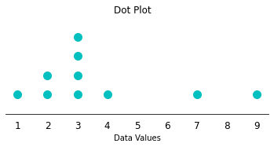

```python
x=[1, 2, 2, 3, 3, 3, 3, 4, 7, 9]
dotplots(x)
```

Example: The dataset below is the waiting time, in minutes, of customers at a fast food restaurant. Construct a dot plot.

`2, 4, 7, 5, 3, 9, 6, 4, 2, 7, 7, 7, 4, 7, 9`

First run(execute) the `dotplots(x)` above.

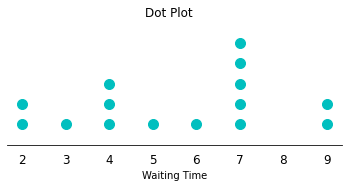

```python
x = [2, 4, 7, 5, 3, 9, 6, 4, 2, 7, 7, 7, 4, 7, 9]
dotplots(x, "Waiting Time")
```

## 5.6 Stem and leaf Plots

We need to install **Stemgraphic** for plotting stem-and-leaf plot. This is because Stemgraphic is not included in any of the Python Libraries. To install Stemgraphic type the following syntax. Stemgraphic Modules Link

Note: Stemplots (Stem-and-Leaf plots) should only be used for small datasets.

```python
pip install stemgraphic
```

The output generated by the installation process has been deleted above. It is not important.

After stemgraphic is properly installed use the syntax below to plot a stem-and-leaf plot with dataset saved in `x`.

```
import stemgraphic
stemgraphic.stem_graphic(x, scale = 10,aggregation=False)
```

Note: We need to execute(run) `pip install stemgraphic` for every new session to graph stem-and-leaf plot.

Example: The dataset below is exam scores. Construct stem-and-leaf plot.

```
33, 42, 49, 49, 53, 55, 55, 61, 63, 67, 68, 68, 69, 69, 72,
                  73, 74, 78, 80, 83, 88, 88, 88, 90, 92, 94, 94, 94, 94, 96,
                  100
```

[Watch demo video](https://youtu.be/D3zNpjYvGW0)

1. Click `+ Code`
2. Type `pip install stemgraphic`
3. Click `play` button
4. Click `+ Code`
5. Type `import stemgraphic`
6. Type

   ```
   x = [33, 42, 49, 49, 53, 55, 55, 61, 63, 67, 68, 68, 69,
                       69, 72, 73, 74,78, 80, 83, 88, 88, 88, 90, 92, 94, 94, 94,
                       94, 96, 100]
   ```

7. Type `stemgraphic.stem_graphic(x,scale=10,aggregation=False)`
8. Click `play` button

[output not shown]

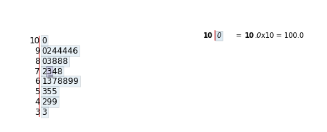

```python
import stemgraphic
x = [33, 42, 49, 49, 53, 55, 55, 61, 63, 67, 68, 68, 69, 69, 72, 73, 74,
           78, 80, 83, 88, 88, 88, 90, 92, 94, 94, 94, 94, 96, 100]
stemgraphic.stem_graphic(x,scale=10,aggregation=False)
```

```
[81, 21, 53, 32, 80, 13, 26, 42, 35, 41, 14, 25, 87, 62, 46,
                  40, 32, 52, 85, 28, 17, 36, 83, 79, 18, 50, 17, 36, 36,
                  19]
```

[output not shown]

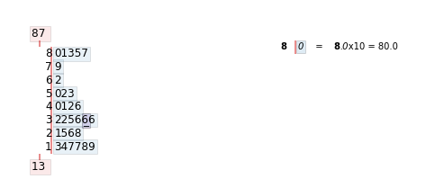

```python
import stemgraphic

x = [81, 21, 53, 32, 80, 13, 26, 42, 35, 41, 14, 25, 87, 62, 46, 40, 32,
       52, 85, 28, 17, 36, 83, 79, 18, 50, 17, 36, 36, 19]

stemgraphic.stem_graphic(x,scale = 10,aggregation=False)
```

## 5.7 Scatter Plots

[Watch demo video](https://youtu.be/fhgYqcvlx5k)

A data set with a pair of quantitative variables can be displayed with a scatter plot.

Example: Age in years and the corresponding height in centimeters is given below. Draw a scatter plot.

| age(yrs) | Height(cm) |
| --- | --- |
| 5 | 95 |
| 6 | 100 |
| 7 | 105 |
| 8 | 107 |
| 9 | 110 |
| 10 | 115 |

1. Click `+ Code`
2. Type `import matplotlib.pyplot as plt`
3. Type `x = [5,6,7,8,9,10]`
4. Type `y = [95,100,105,107,110,115]`
5. Type `plt.scatter(x,y)`
6. Type `plt.suptitle('Scatter Plot Age vs Height')`
7. Type `plt.xlabel('Age(yrs)')`
8. Type `plt.ylabel('Height(cm)')`
9. Click `play` button

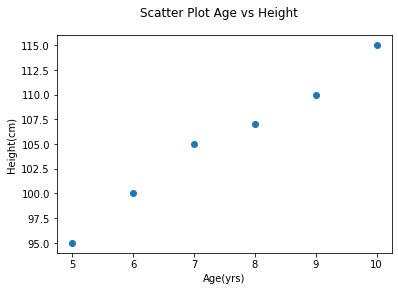

```python
import matplotlib.pyplot as plt

x = [5,6,7,8,9,10]
y = [95,100,105,107,110,115]

plt.scatter(x,y)

plt.suptitle('Scatter Plot Age vs Height')
plt.xlabel('Age(yrs)')
plt.ylabel('Height(cm)')
```

# 6. Measures of Center and Variation

[Watch demo video](https://youtu.be/oZKsKO9eJz4)

A numerical value that is representative of the dataset located at the "center". The three most widely used measures of the center of a data are the mean (average), the median and mode.

## 6.1 Mean and Median

### The Mean

The sample mean of a data set $x_1, x_2, x_3, ..., x_n$ is $\bar{x}=\frac{\Sigma x_i}{n}$

The population mean of the a set $x_1, x_2, x_3, ..., x_N$ is $\mu=\frac{\Sigma x_i}{N}$

numpy syntax for the mean:

```
import numpy as np
x = [x1,x2,x3,...,xn]
np.mean(x)
```

Example: find the mean of the data set `1,2,3` using `numpy.mean()`.

1. Click `+ Code`
2. Type `import numpy as np`
3. Type `x = [1,2,3]`
4. Type `np.mean(x)`
5. Click `play` button

```python
import numpy as np
x = [1,2,3]
np.mean(x)
```

```
2.0
```

Interpretation: the mean is 2.0

### The Median

The median of a data set is the middle number after the data is ordered from smallest to highest.

numpy syntax for median:

```
import numpy as np
x = [x1,x2,x3,...,xn]
np.median(x)
```

Example: find the median of the data set `1,2,3,4`

```python
import numpy as np
x = [1,2,3,4]
np.median(x)
```

```
2.5
```

Interpretation: the median is 2.5

```
45288, 96096, 69468, 79872, 92520, 49968, 76248, 110076,
                  84324, 101496, 100668, 66864, 49968, 101496, 49968, 69468,
                  69468, 96096, 100716, 73380, 52044, 76248, 66864, 66864,
                  76848, 66864, 139392, 56280, 69468, 66864,73380, 87564, 49968,
                  49968, 76848
```

```python
import numpy as np

x= [45288, 96096, 69468, 79872, 92520, 49968, 76248, 110076, 84324, 101496,
    100668, 66864, 49968, 101496, 49968, 69468, 69468, 96096, 100716, 73380,
    52044, 76248, 66864, 66864, 76848, 66864, 139392, 56280, 69468, 66864,73380,
    87564, 49968, 49968, 76848]

print("the mean and median using numpy")
print(np.mean(x))
print(np.median(x))
```

```
the mean and median using numpy
75968.91428571429
73380.0
```

Interpretation: The mean is 75968.914286 and the median is 73380.0.

**Mode**

For mode use `np.unique(x,return_counts=True)` to display each value with its frequency. Select values with highest frequencies.

Example: What is the mode of `x = [1,1,2,2,2,3,3,5,5,5]`

```python
import numpy as np
x =  [1,1,2,2,2,3,3,5,5,5]
np.unique(x,return_counts=True)
```

```
(array([1, 2, 3, 5]), array([2, 3, 2, 3]))
```

**Interpretation**: From the frequency array ([2, 3, 2, 3]), the and fourth values have the highest frequency 3. Thus, the mode are 2 and 5.

Note: Mode using pandas library is covered in advanced topics here.

## 6.2 The Variance

[Watch demo video](https://youtu.be/JRPUHbUmwL0)

How spread out are the data values from the "center"? The most common measures of variation, or spread, of data are the standard deviation and variance.

The variance of a data set is the average of the squared deviations(distances) of the data values from the mean.

1. The sample variance of the data set $x_1, x_2, x_3, ..., x_n$ is given by $s^2=\frac{\Sigma (x_i-\mu)^2}{n-1}$
2. The population variance of the data set $x_1, x_2, x_3, ..., x_N$ is given by $\sigma^2=\frac{\Sigma (x_i-\mu)^2}{N}$

numpy syntax for sample variance:

```
import numpy as np
x = [x1,x2,x3,...]
np.var(x,ddof=1)    is (n-ddof)
```

numpy syntax for population variance:

```
import numpy as np
x = [x1,x2,x3,...]
np.var(x)
```

**Note**: `ddof` degrees of freedom for numerator is 1 for sample and 0 for population variance. `ddof=0` by default in numpy.

Example: find the sample variance of the dataset `1,2,3,4,5`

1. Click `+ Code`
2. Type `import numpy as np`
3. TYpe `x = [1,2,3,4,5]`
4. Type `np.var(x,ddof=1)`
5. Click `play` button

```python
import numpy as np
x = [1,2,3,4,5]
np.var(x,ddof=1)
```

```
2.5
```

Interpretation: The sample variance is 2.5

Example: find the population variance of the data set `1,2,3,4,5`

```python
import numpy as np
x = [1,2,3,4,5]
np.var(x)      #in numpy ddof=0 by default
```

```
2.0
```

Interpretation: The population variance is 2.0

Example: The salaries for the eight Board of Ethics workers for the City of Chicago are listed below. Write a `numpy` program to calculate the **population variance**.

```
139740, 100716, 80844, 124056, 79812, 87564, 96096,
                  96096
```

```python
import numpy as np
x = [139740, 100716, 80844, 124056, 79812, 87564, 96096, 96096]

np.var(x,ddof=0)
```

```
389385609.75
```

Interpretation: The population variance for the given salaries is 389385609.75

## 6.3 The Standard Deviation

The standard deviation is the square root of the variance.

numpy for sample standard deviation:

```
import numpy as np
x = [x1,x2,x3,...]
np.std(x,ddof=1)
```

numpy for population standard deviation:

```
import numpy as np
x = [x1,x2,x3,...]
np.std(x)
```

Example: find the sample standard deviation (std) of the data set `1,2,3,4,5`

```python
import numpy as np
x = [1,2,3,4,5]
np.std(x,ddof=1)
```

```
1.5811388300841898
```

Interpretation: The sample standard deviation is 1.5811388300841898

Example: find the population standard deviation of the data set `1,2,3,4,5`

```python
import numpy as np
x = [1,2,3,4,5]
np.std(x)
```

```
1.4142135623730951
```

Interpretation: The population standard deviation is 1.4142135623730951

```
77.3, 80.3, 76, 80.5, 81.5, 81.9, 81.3, 85.2, 81, 80.9, 79.7,
                  83.4, 84.4, 80.6, 80.3, 79.6, 79.8, 79.6, 79.5, 80.5, 79.8,
                  80.3, 74.5, 79.5, 71.9, 68.8, 71.7, 78.9, 72.1, 82.2, 81.4,
                  85, 80.6, 81.9, 74.1, 73.6, 69.8, 74.1, 80.5, 68.9, 82.3,
                  74.5, 72.5, 74, 74.7, 72.7, 71.9, 77.1, 72.9, 76.4, 76.2,
                  78.4, 71.6, 76.4, 77.1, 79.8, 79.5, 80.8, 80.4, 80.2, 74.4,
                  81, 79.2, 77.5, 80.5, 75.2, 70.1, 70.7, 71.1, 78.2, 72.6,
                  80.5, 74.9, 79.6, 75.3, 82.2, 79.8, 77.8
```

```python
import numpy as np
x = [77.3, 80.3, 76, 80.5, 81.5, 81.9, 81.3, 85.2, 81, 80.9, 79.7, 83.4, 84.4,
     80.6, 80.3, 79.6, 79.8, 79.6, 79.5, 80.5, 79.8, 80.3, 74.5, 79.5, 71.9,
     68.8, 71.7, 78.9, 72.1, 82.2, 81.4, 85, 80.6, 81.9, 74.1, 73.6, 69.8, 74.1,
     80.5, 68.9, 82.3, 74.5, 72.5, 74, 74.7, 72.7, 71.9, 77.1, 72.9, 76.4, 76.2,
     78.4, 71.6, 76.4, 77.1, 79.8, 79.5, 80.8, 80.4, 80.2, 74.4, 81, 79.2, 77.5,
     80.5, 75.2, 70.1, 70.7, 71.1, 78.2, 72.6, 80.5, 74.9, 79.6, 75.3, 82.2,
     79.8, 77.8]

np.std(x,ddof=0)
```

```
4.036198185451496
```

Example: A random sample of 35 annual salaries of Animal Control employees of the City of Chicago is listed below. Write a `numpy` program to compute the sample variance and standard deviation.

```
45288, 96096, 69468, 79872, 92520, 49968, 76248, 110076,
                  84324, 101496, 100668, 66864, 49968, 101496, 49968, 69468,
                  69468, 96096, 100716, 73380, 52044, 76248, 66864, 66864,
                  76848, 66864, 139392, 56280, 69468, 66864,73380, 87564, 49968,
                  49968, 76848
```

```python
import numpy as np

x = [45288, 96096, 69468, 79872, 92520, 49968, 76248, 110076, 84324, 101496,
     100668, 66864, 49968, 101496, 49968, 69468, 69468, 96096, 100716, 73380,
     52044, 76248, 66864, 66864, 76848, 66864, 139392, 56280, 69468, 66864,
     73380, 87564, 49968, 49968, 76848]

print('The sample variance and standard deviation are')
print(np.var(x,ddof=1))
print(np.std(x,ddof=1))
```

```
The sample variance and standard deviation are
438099876.7865547
20930.835549173727
```

Interpretation: The sample variance and standard deviation are 438099876.7865547 and 20930.835549173727 respectively.

## Weighted Mean and std

[Watch demo video](https://youtu.be/0XJCYtcAbL0)

numpy syntax for weighted mean and std:

```
import numpy as np
x = [x1,x2,x3,...]
w = [w1,w2,w3,...]

np.average(x,weights=w)
```

numpy sample standard deviation:

```
import numpy as np
(np.cov(x,aweights=w))**(1/2)
```

Example: At the end of a term a student received a B in Biology (3 credits), A in History (3 credits), B in English Literature (4 credits), and C in Mathematics (5 credits). Find the students grade point average (GPA). Note: A = 4, B = 3, C = 2, D = 1 F = 0 grade points). GPAs are weighted mean. Find the weighted standard-deviation.

```python
import numpy as np
x = [3,4,3,2]
w = [3,3,4,5]

np.average(x,weights=w)
```

```
2.8666666666666667
```

```python
(np.cov(x,aweights=w))**.5
```

```
0.8359396992145376
```

Interpretation: The grade point average (GPA) is 2.87 with standard deviation 0.84

### Mean and Standard deviation of Grouped Frequency Tables

Sometimes instead of the raw data, we are given a summary frequency table.

Example: Below is a frequency table of quiz scores from 26 students. Find the mean and standard deviation. In this case, we take the midpoint of each class to represent the class score.

| class | midpoint | freq |
| --- | --- | --- |
| 0-2 | 1 | 1 |
| 3-5 | 4 | 6 |
| 6-8 | 7 | 10 |
| 9-11 | 10 | 7 |
| 12-14 | 13 | 0 |
| 15-17 | 16 | 2 |

numpy syntax for mean and std with frequency as weight:

```
import numpy as np
np.average(x,weights=freq)
```

numpy sample standard deviation:

```
import numpy as np
(np.cov(x,fweights=freq),ddof=1)**(1/2)
```

Example: Below is a frequency table of quiz scores from 26 students. Find the mean and standard deviation. In this case, we take the midpoint of each class to represent the class score.

| class | midpoint | freq |
| --- | --- | --- |
| 0-2 | 1 | 1 |
| 3-5 | 4 | 6 |
| 6-8 | 7 | 10 |
| 9-11 | 10 | 7 |
| 12-14 | 13 | 0 |
| 15-17 | 16 | 2 |

1. Click `+ Code`
2. Type `import numpy as np`
3. Type `mid_points = [1,4,7,10,13,16]`
4. Type `freq = [1,6,10,7,0,2]`
5. Type `np.average(mid_points,weights=freq)`
6. Click `play` button

```python
import numpy as np
mid_points = [1,4,7,10,13,16]
freq = [1,6,10,7,0,2]
np.average(mid_points,weights=freq)
```

```
7.576923076923077
```

Interpretation: the mean is 7.576923076923077

```python
import numpy as np
mid_points = [1,4,7,10,13,16]
freq = [1,6,10,7,0,2]
(np.cov(mid_points,fweights=freq,ddof=1))**.5
```

```
3.5005494074282333
```

Interpretation: the sample standard deviation is 3.5005494074282333

```python
import numpy as np

mid_points = [1,4,7,10,13,16]
freq = [1,6,10,7,0,2]
np.sqrt(np.cov(mid_points,fweights=freq,ddof=0))
```

```
3.432571103225427
```

Interpretation: The population standard deviation is 3.432571103225427

# 7. Measures of Position

Measure of the relative location of a data value in the dataset.

## 7.1 Percentiles (Quantiles)

[Watch demo video](https://youtu.be/B8Xzw9hdqTM)

The p$^{th}$ percentile is the value that is greater than (or equal to) p percent of the ordered data.

- $1^{st}$ quartile is equal to $25^{th}$ percentile
- $2^{nd}$ quartile is equal to $50^{th}$ percentile
- $3^{rd}$ quartile is equal to $75^{th}$ percentile

In Python percentiles are called **quantiles**

numpy syntax for percentile

```
import numpy as np
np.quantile(x,p)
```

**Note**: `p` is the percentile in decimals. For example, the 70th percentile has `p` value of 0.70, for 1st Quartile which is the same as 25th Percentile, `p = .25`

To display the 25th, 50th and 75th percentiles in one line, use the syntax

```
np.quantile(x,[.25,0.5,0.75])
```

1. Click `+ Code`
2. Type `import numpy as np`
3. Type

   ```
   x=[81, 21, 53, 32, 80, 13, 26, 42, 35, 41, 14, 25, 87, 62,
                       46, 40, 32, 52, 85, 28, 17, 36, 83, 79, 18, 50, 17, 36, 36,
                       19]
   ```

4. Type `np.quantile(x,.7)`
5. Click `play` button

```python
import numpy as np
x=[81, 21, 53, 32, 80, 13, 26, 42, 35, 41, 14, 25, 87, 62, 46, 40, 32,
           52, 85, 28, 17, 36, 83, 79, 18, 50, 17, 36, 36, 19]
np.quantile(x,.7)
```

```
50.599999999999994
```

Interpretation: The 70th percentile is approximately 50.6

```
81, 21, 53, 32, 80, 13, 26, 42, 35, 41, 14, 25, 87, 62, 46,
                  40, 32, 52, 85, 28, 17, 36, 83, 79, 18, 50, 17, 36, 36,
                  19
```

1. Find the 70th percentile.
2. Find the 83rd percentile.
3. Find the 1st quartile.
4. Find the 3rd quartile.

Note: These results could be different from other results that use a different method of computing percentiles.

```python
import numpy as np
x=[81, 21, 53, 32, 80, 13, 26, 42, 35, 41, 14, 25, 87, 62, 46, 40, 32,
           52, 85, 28, 17, 36, 83, 79, 18, 50, 17, 36, 36, 19]
np.quantile(x,[.70,.83,.25,.75])
```

```
array([50.6 , 79.07, 25.25, 52.75])
```

Interpretation:

| Percentile | score |
| --- | --- |
| 70th | 50.60 |
| 83rd | 79.07 |
| 25th | 25.25 |
| 75th | 52.75 |

```
81, 21, 53, 32, 80, 13, 26, 42, 35, 41, 14, 25, 87, 62, 46,
                  40, 32, 52, 85, 28, 17, 36, 83, 79, 18, 50, 17, 36, 36,
                  19
```

- Find the Interquartile range.

Note: These results could be different from other results that use a different method of computing percentiles.

```python
import numpy as np
x=[81, 21, 53, 32, 80, 13, 26, 42, 35, 41, 14, 25, 87, 62, 46, 40, 32,
           52, 85, 28, 17, 36, 83, 79, 18, 50, 17, 36, 36, 19]
np.quantile(x,[.70,.83,.25,.75])
IQR = np.quantile(x,.75)-np.quantile(x,.25)    # IQR = Q3 - Q1
IQR
```

```
27.5
```

Example: A random sample of 35 annual salaries of Animal Control employees of the City of Chicago is listed below. Write a `numpy` program to compute the 90th percentile, 2nd quartile and 10th percentile.

```
45288, 96096, 69468, 79872, 92520, 49968, 76248, 110076,
                  84324, 101496, 100668, 66864, 49968, 101496, 49968, 69468,
                  69468, 96096, 100716, 73380, 52044, 76248, 66864, 66864,
                  76848, 66864, 139392, 56280, 69468, 66864,73380, 87564, 49968,
                  49968, 76848
```

```python
import numpy as np

x = [45288, 96096, 69468, 79872, 92520, 49968, 76248, 110076, 84324, 101496,
     100668, 66864, 49968, 101496, 49968, 69468, 69468, 96096, 100716, 73380,
     52044, 76248, 66864, 66864, 76848, 66864, 139392, 56280, 69468, 66864,
     73380, 87564, 49968, 49968, 76848]

np.quantile(x,[0.90,0.50,0.10])
```

```
array([101184.,  73380.,  49968.])
```

## Percentile of a Value in a Data Set

In a given dataset, what is the percentile (rank) of a given data value? That is, how many or what percent of the data values are below or at the given data value.

For this, we need to import the stats function from the SciPy library.

## 7.2 The SciPy Library

**The scipy.stats module** This module from SciPy contains a large number of *probability distributions* as well as a growing library of *statistical functions*. We will use it extensively in our probability and inferential statistics sections later.

stats syntax for percentile rank

```
from scipy import stats
stats.percentileofscore(x, data_value, kind='rank')
```

```
81, 21, 53, 32, 80, 13, 26, 42, 35, 41, 14, 25, 87, 62, 46,
                  40, 32, 52, 85, 28, 17, 36, 83, 79, 18, 50, 17, 36, 36,
                  19
```

[Watch demo video](https://youtu.be/8W6o2XKPbnY)

```python
from scipy import stats

x = [81, 21, 53, 32, 80, 13, 26, 42, 35, 41, 14, 25, 87, 62, 46, 40,
             32, 52, 85, 28, 17, 36, 83, 79, 18, 50, 17, 36, 36, 19]

stats.percentileofscore(x,50,kind='rank')
```

```
70.0
```

Interpretation: A student with an exam score of 50 is in the 70th percentile. This student's score is at or better than 70 percent of the students. Or, 70% of the scores are at or below 50.

Example: Below is the list of ages of US Senators (2020). Write a program to compute the percentile age rank of a Senator aged 50. [Watch demo video](https://watch.screencastify.com/v/arpeGd30ygK2P0sOgk5T)

```
81,81,80,80,80,80,78,78,78,77,77,75,75,74,74,74,73,72,72,71,71,71,71,70
                  ,70,
                  70,70,68,68,68,68,68,67,67,67,66,66,65,65,65,65,64,64,64,64,64,64,63,63,
                  63,63,62,62,62,62,62,61,61,61,60,60,59,59,59,59,59,59,59,59,58,58,57,57,
                  56,56,55,54,54,54,54,54,53,53,52,52,52,52,52,51,50,49,48,46,45,44,43,43,
                  43,42,41
```

```python
import numpy as np
from scipy import stats

age = [81,81,80,80,80,80,78,78,78,77,77,75,75,74,74,74,73,72,72,71,71,71,71,70,70,
        70,70,68,68,68,68,68,67,67,67,66,66,65,65,65,65,64,64,64,64,64,64,63,63,
        63,63,62,62,62,62,62,61,61,61,60,60,59,59,59,59,59,59,59,59,58,58,57,57,
        56,56,55,54,54,54,54,54,53,53,52,52,52,52,52,51,50,49,48,46,45,44,43,43,
        43,42,41]

age_array = np.array(age)   # convert the list to a numpy array

stats.percentileofscore(age_array,50,kind='rank')
```

```
11.0
```

Interpretation: The percentile age rank of a Senator aged 50 is 11.

## Min and Max

To find the minimum and maximum values of a data set, you can use the list method or numpy as follows:

```
x = [x1, x2, x3, ...]

max(x)             # list max x is a Python list
min(x)             # list min

np.amax(x)         #Numpy max x is numpy array
np.amin(x)         #Numpy min
```

```
81, 21, 53, 32, 80, 13, 26, 42, 35, 41, 14, 25, 87, 62, 46,
                  40, 32, 52, 85, 28, 17, 36, 83, 79, 18, 50, 17, 36, 36,
                  19
```

```python
import numpy as np
x = [81, 21, 53, 32, 80, 13, 26, 42, 35, 41, 14, 25, 87, 62, 46, 40,
             32, 52, 85, 28, 17, 36, 83, 79, 18, 50, 17, 36, 36, 19]

print('min is',np.amin(x))
print('max is',np.amax(x))
```

```
min is 13
max is 87
```

```
81,81,80,80,80,80,78,78,78,77,77,75,75,74,74,74,73,72,72,71,71,71,71,70
                  ,70,
                  70,70,68,68,68,68,68,67,67,67,66,66,65,65,65,65,64,64,64,64,64,64,63,63,
                  63,63,62,62,62,62,62,61,61,61,60,60,59,59,59,59,59,59,59,59,58,58,57,57,
                  56,56,55,54,54,54,54,54,53,53,52,52,52,52,52,51,50,49,48,46,45,44,43,43,
                  43,42,41
```

```python
import numpy as n
x = [81,81,80,80,80,80,78,78,78,77,77,75,75,74,74,74,73,72,72,71,71,71,71,70,70,
        70,70,68,68,68,68,68,67,67,67,66,66,65,65,65,65,64,64,64,64,64,64,63,63,
        63,63,62,62,62,62,62,61,61,61,60,60,59,59,59,59,59,59,59,59,58,58,57,57,
        56,56,55,54,54,54,54,54,53,53,52,52,52,52,52,51,50,49,48,46,45,44,43,43,
        43,42,41]
print('the min age is', np.min(x))
print('the max age is', np.max(x))
print('the first quartile is',np.quantile(x,.25))
print('the second quartile is',np.quantile(x,.5))
print('the third quartile is',np.quantile(x,.75))
```

```
the min age is 41
the max age is 81
the first quartile is 55.75
the second quartile is 63.0
the third quartile is 70.0
```

Interpretation: the minimum, 1st quartile, 2nd quartile, 3rd quartile and maximum age are 41, 55.75, 63, 70 and 81 respectively.